# Epiclim Liver Lipidomic - F0 adult females

Baptiste Ducarme

2025-10-14

# 1 Introduction

This script was used to perform liver lipid profiling in adult female zebrafish (15.5–16.5 months post-fertilization) following developmental exposure (2 hpf to 28 dpf) to combined climate stressors, including acidification (pH 6.35) and elevated temperature (32°C), as well as PFOS exposure (nominal concentration: 2 µg/L), using a 2 × 2 × 2 factorial design.

The lipidomic data, consisting of m/z, retention time features and their associated intensities, were first preprocessed in MZmine, including peak detection, alignment, normalization to internal standards, and filtering based on the %RSD of pooled quality control samples. The resulting dataset, used for all downstream analyses, contained both identified and unidentified features across all samples.

The data were first filtered to retain only features present in at least three samples per condition. To address the few missing values, K-nearest neighbor (KNN) imputation was applied, followed by log2 transformation and Pareto scaling to stabilize variance and approximate normality.

Principal component analysis (PCA) was then performed on the transformed data to visualize the overall sample distribution. Differential analysis was conducted using the limma framework, with experimental condition and exposure included as model factors. Contrasts of interest were defined for each condition versus the control, and MA plots were generated as diagnostic plots. In addition to determining whether each combination treatment elicited a response beyond that predicted by the corresponding individual stressors, pairwise comparisons were performed between each combination treatment and its respective single-stressor treatments.

From the limma output for the condition-versus-control contrasts, the m/z, retention time, t-statistic, and raw p-value were extracted for subsequent pathway analysis. Pathway enrichment analysis was conducted using Mummichog (version 2) in positive-ionization mode, with a mass tolerance of 5 ppm and enforcement of primary ions. The top 10% of peaks ranked by p-value were selected as the significance cutoff. The *Danio rerio* (`dre_mtf`) pathway library was used, including only pathway sets containing at least three features. To estimate the null distribution, 100 random permutations were performed. Statistically significant metabolic pathway alterations were defined as those with a Gamma p-value < 0.05 and Hits sig ≥ 3.

# 2 Load required packages

```r
library("readxl") # open data
library("dplyr") # code in pipe
library("ggplot2") # for graph
library("rstatix") # Analyse stat
library("gridExtra") # For graph alignment
library("ggpubr")# for stat link with ggplot
library("lubridate") #for timpoint analysis
library("multcomp")# stat and letter
library('AER')# stat and letter
library("stringr")
library("ggExtra") # PCA
library("tidyverse") # includes ggplot2, for data visualisation. dplyr, for data manipulation.
library("RColorBrewer") # for a colourful plot
library("ggrepel") # for nice annotations

R.version
```

```
##                _
## platform       aarch64-apple-darwin20
## arch           aarch64
## os             darwin20
## system         aarch64, darwin20
## status
## major          4
## minor          4.3
## year           2025
## month          02
## day            28
## svn rev        87843
## language       R
## version.string R version 4.4.3 (2025-02-28)
## nickname       Trophy Case
```

# 3 Working environment setup

```r
setwd("/Users/baptisteducarme/Desktop/EpiCLim-F0-liver-female/Lipids")
rm(list = ls()) # clean the global environment, good coding practice
```

# 4 Import dataset

```r
counts <- read_excel("/Users/baptisteducarme/Desktop/EpiCLim-F0-liver-female/Lipids/EPICLIM_F0_Liver_Lipid_Females.xlsx",sheet = "NormData")
```

## 4.1 Data treatment

```r
count<-as.matrix(counts)
head(counts)
```

```
## # A tibble: 6 × 42
##   Compound       Lv_r002 Lv_r003 Lv_r004 Lv_r006 Lv_r007 Lv_r008 Lv_r009 Lv_r010
##   <chr>            <dbl>   <dbl>   <dbl>   <dbl>   <dbl>   <dbl>   <dbl>   <dbl>
## 1 acetylcarniti…    1.70    78.4  115.    648.     12.4    39.5   504.    246.
## 2 CE fragment: …   NA     1608.  1380.   1596.   1822.     29.5   942.   1491.
## 3 Cer(d18:1/16:…    1.14   109.    53.8    61.6    23.3     3.12   18.8    82.9
## 4 Cer(d18:1/18:…    4.96    44.4   24.1    27.7    25.6     6.38    9.75   24.2
## 5 Cer(d18:1/18:…   NA       15.6    1.07    1.00    4.03   NA      NA       4.27
## 6 Cer(d18:1/22:…   NA      430.   240.    237.     52.3    16.5    43.4   196.
## # ℹ 33 more variables: Lv_r011 <dbl>, Lv_r012 <dbl>, Lv_r013 <dbl>,
## #   Lv_r014 <dbl>, Lv_r016 <dbl>, Lv_r017 <dbl>, Lv_r018 <dbl>, Lv_r019 <dbl>,
## #   Lv_r020 <dbl>, Lv_r021 <dbl>, Lv_r025 <dbl>, Lv_r028 <dbl>, Lv_r032 <dbl>,
## #   Lv_r034 <dbl>, Lv_r036 <dbl>, Lv_r037 <dbl>, Lv_r038 <dbl>, Lv_r041 <dbl>,
## #   Lv_r043 <dbl>, Lv_r046 <dbl>, Lv_r049 <dbl>, Lv_r053 <dbl>, Lv_r055 <dbl>,
## #   Lv_r056 <dbl>, Lv_r058 <dbl>, Lv_r059 <dbl>, Lv_r060 <dbl>, Lv_r062 <dbl>,
## #   Lv_r067 <dbl>, Lv_r071 <dbl>, Lv_r074 <dbl>, Lv_r077 <dbl>, Lv_r079 <dbl>
```

```r
# Convert to matrix
counts_matrix <- as.matrix(counts)

# Lipid matrix with the first column as name
Lipid_names <- counts[[1]]
counts_matrix <- as.matrix(counts[,-1])
counts_matrix <- matrix(as.numeric(counts_matrix), nrow = nrow(counts_matrix))
rownames(counts_matrix) <- Lipid_names
colnames(counts_matrix) <- colnames(counts)[-1]
head(counts_matrix,1)
```

```
##                                         Lv_r002  Lv_r003  Lv_r004  Lv_r006
## acetylcarnitine@0.71_mz204.1264_ID2825 1.703361 78.44126 115.0374 648.1885
##                                         Lv_r007  Lv_r008  Lv_r009  Lv_r010
## acetylcarnitine@0.71_mz204.1264_ID2825 12.36054 39.49107 504.3979 245.8444
##                                         Lv_r011  Lv_r012  Lv_r013  Lv_r014
## acetylcarnitine@0.71_mz204.1264_ID2825 547.2112 57.06286 79.35168 354.9598
##                                         Lv_r016  Lv_r017 Lv_r018 Lv_r019
## acetylcarnitine@0.71_mz204.1264_ID2825 208.3205 19.08613      NA 2.37245
##                                         Lv_r020  Lv_r021  Lv_r025  Lv_r028
## acetylcarnitine@0.71_mz204.1264_ID2825 127.6328 162.5682 112.1815 798.5098
##                                         Lv_r032 Lv_r034 Lv_r036  Lv_r037
## acetylcarnitine@0.71_mz204.1264_ID2825 642.3868      NA 435.381 64.96295
##                                         Lv_r038  Lv_r041  Lv_r043  Lv_r046
## acetylcarnitine@0.71_mz204.1264_ID2825 816.8169 3.440863 168.5701 394.3887
##                                         Lv_r049  Lv_r053  Lv_r055  Lv_r056
## acetylcarnitine@0.71_mz204.1264_ID2825 154.1785 50.24274 230.3174 73.86855
##                                         Lv_r058  Lv_r059  Lv_r060 Lv_r062
## acetylcarnitine@0.71_mz204.1264_ID2825 310.0317 66.39661 23.31326 285.273
##                                         Lv_r067 Lv_r071  Lv_r074  Lv_r077
## acetylcarnitine@0.71_mz204.1264_ID2825 52.98071  106.41 347.3287 336.0352
##                                         Lv_r079
## acetylcarnitine@0.71_mz204.1264_ID2825 326.6523
```

```r
tail(counts_matrix,1)
```

```
##                             Lv_r002 Lv_r003  Lv_r004  Lv_r006  Lv_r007  Lv_r008
## NI@6.78_mz749.5890_ID71961 1.875769  180.27 136.4699 102.0006 41.66251 3.316402
##                             Lv_r009  Lv_r010  Lv_r011  Lv_r012  Lv_r013
## NI@6.78_mz749.5890_ID71961 10.51079 144.7132 92.93338 5.791676 103.9435
##                             Lv_r014  Lv_r016  Lv_r017  Lv_r018  Lv_r019
## NI@6.78_mz749.5890_ID71961 17.57896 181.6402 25.48242 1.038354 24.72295
##                             Lv_r020  Lv_r021  Lv_r025  Lv_r028  Lv_r032
## NI@6.78_mz749.5890_ID71961 495.1529 164.8362 16.36714 95.09822 473.2564
##                              Lv_r034  Lv_r036  Lv_r037  Lv_r038  Lv_r041
## NI@6.78_mz749.5890_ID71961 0.4526088 50.30613 29.60961 12.09295 29.57252
##                             Lv_r043  Lv_r046  Lv_r049  Lv_r053  Lv_r055
## NI@6.78_mz749.5890_ID71961 1.980621 48.65453 17.32296 232.2926 1.857253
##                             Lv_r056  Lv_r058 Lv_r059  Lv_r060 Lv_r062  Lv_r067
## NI@6.78_mz749.5890_ID71961 42.23073 71.63239  6.0047 140.4252 151.619 37.25681
##                            Lv_r071  Lv_r074  Lv_r077 Lv_r079
## NI@6.78_mz749.5890_ID71961 2.63172 10.28994 3.386598 56.5923
```

```r
str(counts_matrix)
```

```
##  num [1:2439, 1:41] 1.7 NA 1.14 4.96 NA ...
##  - attr(*, "dimnames")=List of 2
##   ..$ : chr [1:2439] "acetylcarnitine@0.71_mz204.1264_ID2825" "CE fragment: 0.532@6.04_mz369.3484_ID64382" "Cer(d18:1/16:0)@6.60_mz520.5082_ID69339" "Cer(d18:1/18:0)@7.03_mz566.5520_ID73973" ...
##   ..$ : chr [1:41] "Lv_r002" "Lv_r003" "Lv_r004" "Lv_r006" ...
```

# 5 Import MetaData

```r
metadata<-read_excel("/Users/baptisteducarme/Desktop/EpiCLim-F0-liver-female/Lipids/EPICLIM_F0_Liver_Lipid_Females.xlsx",sheet = "Metadata")
```

## 5.1 MetaData treatment

```r
head(metadata)
```

```
## # A tibble: 6 × 5
##   name    `Fish nb` Condition    Exposure Sex
##   <chr>       <dbl> <chr>        <chr>    <chr>
## 1 Lv_r002        72 AcidPFOS     expo_3   Female
## 2 Lv_r003        47 PFOS         expo_2   Female
## 3 Lv_r004        36 Temp         expo_3   Female
## 4 Lv_r006        46 PFOS         expo_2   Female
## 5 Lv_r007       101 AcidPFOSTemp expo_2   Female
## 6 Lv_r008        33 Temp         expo_3   Female
```

```r
metadata <- metadata %>%rename("Sample"= "name")
metadata <- metadata %>%rename("Fish_nb"= "Fish nb")
colnames(metadata)
```

```
## [1] "Sample"    "Fish_nb"   "Condition" "Exposure"  "Sex"
```

```r
metadata$Sample <- factor(metadata$Sample)
metadata$Condition <- factor(metadata$Condition)
metadata$Exposure <- factor(metadata$Exposure)
metadata$Sex <- factor(metadata$Sex)
metadata$Fish_nb <- factor(metadata$Fish_nb)

library("tibble")
metadata <- column_to_rownames(metadata, var = "Sample")
metadata <- metadata[colnames(counts_matrix), ]

# confirm alignment
all(rownames(metadata) == colnames(counts_matrix))
```

```
## [1] TRUE
```

```r
str(metadata)
```

```
## 'data.frame':    41 obs. of  4 variables:
##  $ Fish_nb  : Factor w/ 33 levels "9","10","11",..: 23 15 11 14 33 9 24 7 30 8 ...
##  $ Condition: Factor w/ 8 levels "Acid","AcidPFOS",..: 2 6 8 6 3 8 7 1 3 8 ...
##  $ Exposure : Factor w/ 2 levels "expo_2","expo_3": 2 1 2 1 1 2 2 1 1 1 ...
##  $ Sex      : Factor w/ 1 level "Female": 1 1 1 1 1 1 1 1 1 1 ...
```

```r
dim(counts_matrix)
```

```
## [1] 2439   41
```

```r
# number of female samples per condition
table(metadata$Condition)
```

```
##
##         Acid     AcidPFOS AcidPFOSTemp     AcidTemp      Control         PFOS
##            5            5            6            5            5            5
##     PFOSTemp         Temp
##            5            5
```

## 5.2 Missing value

[Naniar package](https://naniar.njtierney.com)

[Shadow Matrix](https://cran.r-project.org/web/packages/naniar/vignettes/getting-started-w-naniar.html)

```r
library("naniar")
# diagnostic
mcar_test(as.data.frame(counts_matrix))
```

```
## # A tibble: 1 × 4
##   statistic    df p.value missing.patterns
##       <dbl> <dbl>   <dbl>            <int>
## 1     1689. 32705       1             1128
```

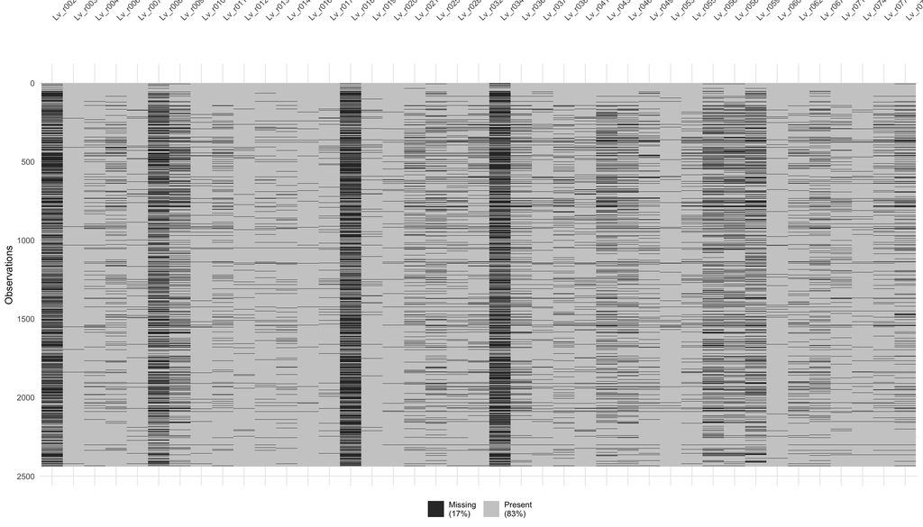

```r
# missing data heatmap
vis_miss(as.data.frame(counts_matrix))
```

*Fig. 1. Heatmap of missing data across samples.* Black squares indicate missing values, and grey squares represent detected metabolites.

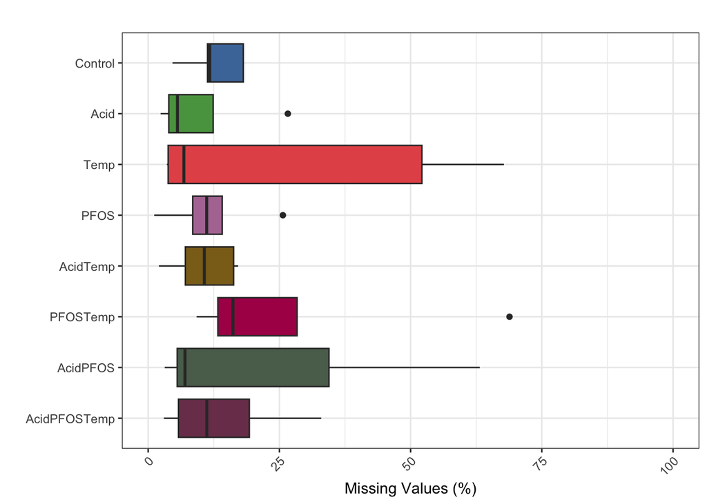

```r
library(dplyr)
library(ggplot2)
# logical matrix of missing values (shadow matrix)
missing_mat <- is.na(counts_matrix)
missing_per_sample <- colMeans(missing_mat) * 100
missing_df <- data.frame( Sample = names(missing_per_sample), MissingPercent = missing_per_sample )
missing_df <- cbind(missing_df, metadata[missing_df$Sample, c("Condition", "Sex")])
# Sort the data
missing_df$Condition <- factor(missing_df$Condition , levels = c("AcidPFOSTemp",
                                                                 "AcidPFOS",
                                                                 "PFOSTemp",
                                                                 "AcidTemp",
                                                                 "PFOS",
                                                                 "Temp",
                                                                 "Acid",
                                                                 "Control"))

ggplot(missing_df, aes(x = MissingPercent, y = Condition, fill = Condition)) +
  geom_boxplot() +
  theme_bw()+
  labs(
    title = "",
    x = "Missing Values (%)",
    y = ""
  ) +
  scale_fill_manual(values = c("Control" = "#4C78A8",
                               "Acid" = "#59A14F",
                               "Temp" = "#E45756",
                               "PFOS" = "#B279A2",
                               "AcidTemp" = "#8C6D1F",
                               "PFOSTemp" = "#AD1457",
                               "AcidPFOS" = "#5B6D5B",
                               "AcidPFOSTemp" = "#7B3F5A")) +
  theme(legend.position = "none",
    axis.text.x = element_text(angle = 45, hjust = 1)) +
  coord_cartesian(xlim = c(0, 100))
```

*Fig. 2. Boxplot showing the percentage of missing data across samples.* Colors indicate the experimental condition.

## 5.3 Filtration

```r
# Convert to long format
long_data <- as.data.frame(counts_matrix) %>%
  rownames_to_column("Compound") %>%
  pivot_longer(
    cols = -Compound,
    names_to = "Sample",
    values_to = "Value")

# add metadata
long_data <- long_data %>%
  left_join(metadata %>%rownames_to_column("Sample"), by = "Sample")

# Count the number of valid replicate per compound, Condition and Sex
valid_counts <- long_data %>%
  group_by(Compound, Condition, Sex) %>%
  summarise(n_valid = sum(!is.na(Value)), .groups = "drop")

# List of valid compound (at least 3 valids replicated per condition and sex)
compound_to_keep <- valid_counts %>%
  group_by(Compound) %>%
  summarise(all_groups_ok = all(n_valid >= 3)) %>%
  filter(all_groups_ok) %>%
  pull(Compound)

# Keep only the valid sample
counts_matrix <- counts_matrix[rownames(counts_matrix) %in% compound_to_keep, ]
```

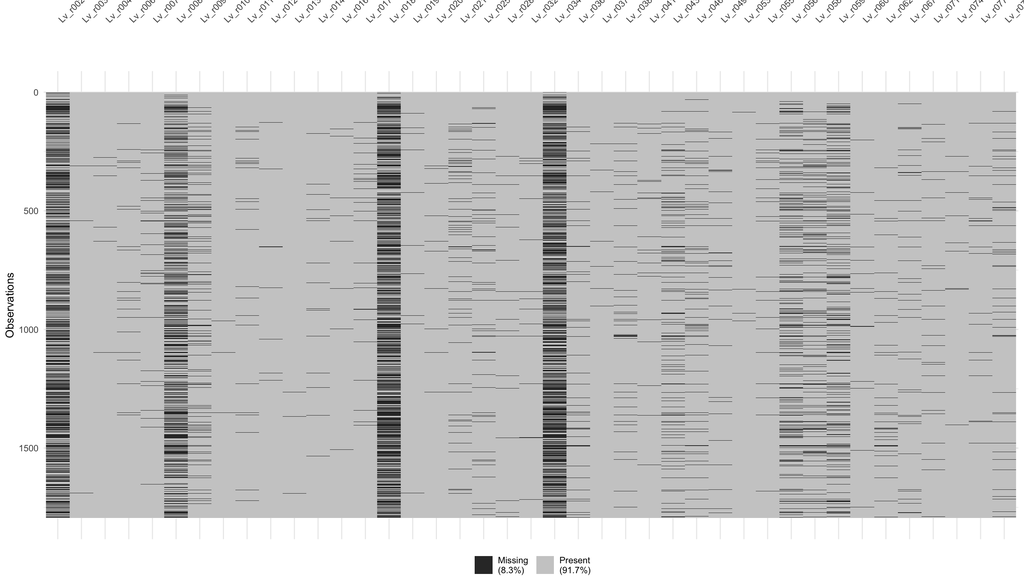

```r
# missing data heatmap
vis_miss(as.data.frame(counts_matrix))
```

*Fig. 3. Heatmap of missing data across samples, after filtration.* Black squares indicate missing values, and grey squares represent detected features.

## 5.4 Inputation (KNN)

[Impute package](https://bioconductor.org/packages/release/bioc/manuals/impute/man/impute.pdf).

Imputation with K-Nearest Neighbors (KNN) estimates missing values in a dataset by considering the values of the closest data points, determined by a distance metric (ussually Euclidean distance). The missing value is then assigned the average of these nearest neighbors’ values, weighted by their proximity ([Sole Galli, 2024](https://www.blog.trainindata.com/knn-imputation-of-missing-values-in-machine-learning/))

**Advantages:**

- Provides more accurate results than simpler methods like mean or median imputation, especially for complex datasets (Accuracy) ([Piyush Kashyap, 2024](https://medium.com/@piyushkashyap045/handling-missing-values-in-data-a-beginner-guide-to-knn-imputation-30d37cc7a5b7)).
- Preserve the original variable distribution (preserves the local structure and relationships within the dataset) ([Sole Galli, 2024](https://www.blog.trainindata.com/knn-imputation-of-missing-values-in-machine-learning/)).
- KNN does not make assumptions about the data distribution, making it flexible for various types of datasets ([Sole Galli, 2024](https://www.blog.trainindata.com/knn-imputation-of-missing-values-in-machine-learning/)).

**Disavantage:**

- Computationally Expensive: KNN requires distance calculations, which can be slow for large datasets [Piyush Kashyap, 2024](https://medium.com/@piyushkashyap045/handling-missing-values-in-data-a-beginner-guide-to-knn-imputation-30d37cc7a5b7).
- KNN algorithms do not scale, so their application is usually limited to smaller dataset ([Sole Galli, 2024](https://www.blog.trainindata.com/knn-imputation-of-missing-values-in-machine-learning/)).
- If too many missing values exist, it struggles to find suitable neighbors ([Taran Kau, 2025](https://medium.com/@tarangds/knn-imputation-the-complete-guide-146f932870a7)).

```r
# removed pooled samples, could affect the imputation methods
metadata <- metadata[metadata$Condition != "Pooled", ]
# Subset centred_counts to only male columns
counts_matrix <- counts_matrix[, rownames(metadata)]
# check dimensions
dim(counts_matrix)
```

```
## [1] 1794   41
```

```r
table(metadata$Condition)
```

```
##
##         Acid     AcidPFOS AcidPFOSTemp     AcidTemp      Control         PFOS
##            5            5            6            5            5            5
##     PFOSTemp         Temp
##            5            5
```

```r
library("impute")
imputed <- impute.knn(as.matrix(counts_matrix))$data
```

```
## Cluster size 1794 broken into 1756 38
## Cluster size 1756 broken into 148 1608
## Done cluster 148
## Cluster size 1608 broken into 1325 283
## Done cluster 1325
## Done cluster 283
## Done cluster 1608
## Done cluster 1756
## Done cluster 38
```

```r
dim(imputed)
```

```
## [1] 1794   41
```

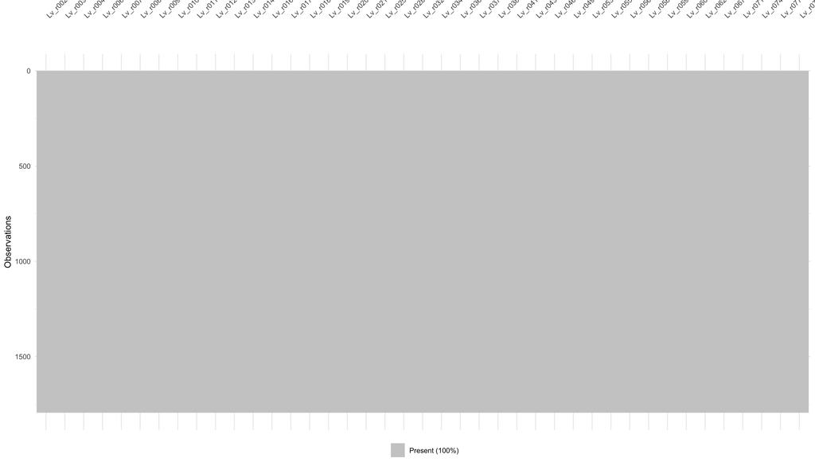

```r
# Missing data heatmap
vis_miss(as.data.frame(imputed))
```

*Fig. 4. Heatmap of missing data across samples, after imputation.* Black squares indicate missing values, and grey squares represent detected metabolites

## 5.5 Transformation

A log transformation helps to remove heteroscedasticity from the data and correct for a skewed data distribution ([Grace & Hudson](http://dx.doi.org/10.5772/65405)).

```r
# add a small constant to avoid log(0)
log_counts <- log2(imputed + 1e-9)

dim(log_counts)
```

```
## [1] 1794   41
```

## 5.6 Pareto scaling

Scaling aims to correct for differences in the magnitude and variance of lipid features by transforming the data relative to a scaling factor. In omics datasets, scaling is applied for several reasons, including reducing differences in feature scale, addressing heteroscedasticity, and improving comparability among subsets of variables with different abundance ranges [(Sun & Xia, 2024)](https://doi.org/10.1016/j.gendis.2023.04.018)..

Pareto scaling provides an intermediate scaling effect between no scaling and unit variance scaling by dividing each mean-centered variable by the square root of its standard deviation [(Sun & Xia, 2024)](https://doi.org/10.1016/j.gendis.2023.04.018).. This approach reduces the influence of highly abundant features while preserving more of the original variance structure compared with unit variance scaling.

In contrast, auto scaling (i.e., mean centering followed by division by the standard deviation) gives equal weight to all variables, which can increase the relative contribution of low-abundance variables that may be more susceptible to measurement error [(Grace & Hudson)](http://dx.doi.org/10.5772/65405).

```r
library("IMIFA")
centred_counts<-pareto_scale(log_counts,centering = TRUE)
```

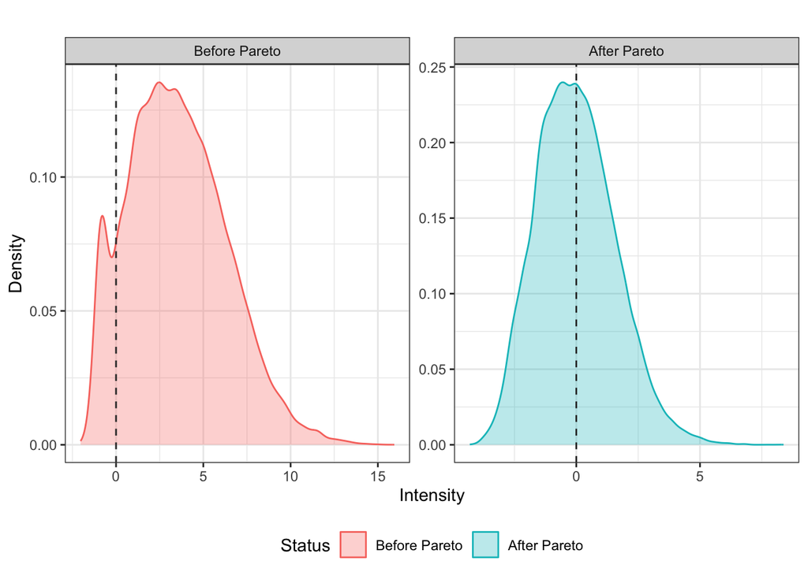

```r
# Log2
df_Log2 <- as.data.frame(log_counts) %>%
  pivot_longer(everything(), names_to = "Sample", values_to = "Intensity") %>%
  mutate(Status = "Before Pareto")

# Pareto
df_Pareto <- as.data.frame(centred_counts) %>%
  pivot_longer(everything(), names_to = "Sample", values_to = "Intensity") %>%
  mutate(Status = "After Pareto")

# combine
df_plot <- bind_rows(df_Log2, df_Pareto)
df_plot$Status <- factor(df_plot$Status, levels = c("Before Pareto", "After Pareto"))

# density plots
ggplot(df_plot, aes(x = Intensity, fill = Status, color = Status)) +
  geom_density(alpha = 0.3) +
  facet_wrap(~Status, scale="free") +
  labs(title = "",
    x = "Intensity",
    y = "Density") +
  theme_bw() +
  theme(legend.position = "bottom") +
  geom_vline(xintercept = 0, linetype = "dashed", color = "grey20")
```

*Fig. 5. Density plot showing data transformation and centering across the entire dataset.* The plot includes data before Pareto scaling (already log2-transformed) and after Pareto scaling (centered and scaled).

# 6 PCA

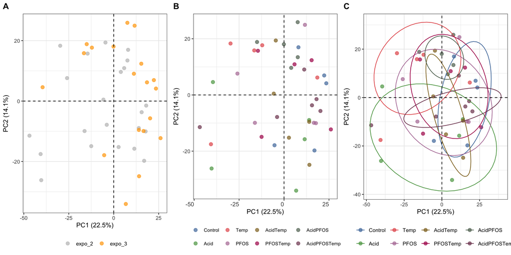

```r
pca_res <- prcomp(t(centred_counts), scale. = FALSE)
var_exp <- round(100 * (pca_res$sdev^2 / sum(pca_res$sdev^2))[1:2], 1)

# PCA dataframe
pca_df <- data.frame(Sample = colnames(centred_counts),
                     PC1 = pca_res$x[,1],
                     PC2 = pca_res$x[,2],
                     Condition = metadata$Condition,
                     Exposure = metadata$Exposure)

pca_df$Condition <- factor(pca_df$Condition, levels = c("Control", "Acid", "Temp", "PFOS", "AcidTemp", "PFOSTemp", "AcidPFOS", "AcidPFOSTemp"))

# Distribution by Exposure
PCA_Female_1 <-ggplot(pca_df, aes(x = PC1, y = PC2, color = Exposure)) +
  geom_point(size = 2.5, alpha = 0.7) +
  scale_color_manual(values = c("expo_2" = "grey", "expo_3" = "orange")) +
  labs(title = "", x = paste0("PC1 (", var_exp[1], "%)"),
       y = paste0("PC2 (", var_exp[2], "%)")) +
  geom_vline(xintercept = 0, color = "black", linetype = "dashed") +
  geom_hline(yintercept = 0, color = "black", linetype = "dashed") +
  theme_bw() +
  theme(legend.position = "bottom", legend.title = element_blank())

PCA_Female_2 <- ggplot(pca_df, aes(x = PC1, y = PC2, color = Condition)) +
  geom_point(size = 2.5, alpha = 0.7) +
  scale_color_manual(values = c("Control" = "#4C78A8",
                               "Acid" = "#59A14F",
                               "Temp" = "#E45756",
                               "PFOS" = "#B279A2",
                               "AcidTemp" = "#8C6D1F",
                               "PFOSTemp" = "#AD1457",
                               "AcidPFOS" = "#5B6D5B",
                               "AcidPFOSTemp" = "#7B3F5A"))  +
  labs(
    title = "",
    x = paste0("PC1 (", var_exp[1], "%)"),
    y = paste0("PC2 (", var_exp[2], "%)")
  ) +
  geom_vline(xintercept = 0, color = "black", linetype = "dashed") +
  geom_hline(yintercept = 0, color = "black", linetype = "dashed") +
  theme_bw() +
  theme(legend.position = "bottom",
        legend.title = element_blank(),
        axis.text.x = element_text(hjust = 1, size = 10),
        strip.text.x = element_text(size = 10),
        legend.text = element_text(size = 8))

PCA_Female_3 <- ggplot(pca_df, aes(x = PC1, y = PC2, color = Condition)) +
  geom_point(size = 2.5, alpha = 0.7) +
  scale_color_manual(values = c("Control" = "#4C78A8",
                               "Acid" = "#59A14F",
                               "Temp" = "#E45756",
                               "PFOS" = "#B279A2",
                               "AcidTemp" = "#8C6D1F",
                               "PFOSTemp" = "#AD1457",
                               "AcidPFOS" = "#5B6D5B",
                               "AcidPFOSTemp" = "#7B3F5A"))  +
  stat_ellipse(level = 0.68, type = "t") +  # 95% CI ellipse
  labs(
    title = "",
    x = paste0("PC1 (", var_exp[1], "%)"),
    y = paste0("PC2 (", var_exp[2], "%)")
  ) +
  geom_vline(xintercept = 0, color = "black", linetype = "dashed") +
  geom_hline(yintercept = 0, color = "black", linetype = "dashed") +
  theme_bw() +
  theme(legend.position = "bottom",
        legend.title = element_blank())

pca_female_df<-pca_df
var_exp_female <- var_exp

ggarrange(PCA_Female_1, PCA_Female_2,PCA_Female_3, ncol = 3, nrow = 1, labels = "AUTO", legend = "bottom")
```

# 7 Limma

[Pipeline limma](https://ucdavis-bioinformatics-training.github.io/2018-June-RNA-Seq-Workshop/thursday/DE.html)

```r
library("limma")
# drop unused factor levels
metadata$Sex <- droplevels(metadata$Sex)
metadata$Condition <- droplevels(metadata$Condition)
metadata$Exposure <- droplevels(metadata$Exposure)

# keep only matching samples in scaled_counts
centred_counts <- centred_counts[, rownames(metadata)]

# confirm alignment
stopifnot(all(colnames(centred_counts) == rownames(metadata)))

# Recreate the design matrix
design <- model.matrix(~ 0 + Condition + Exposure, data = metadata)
colnames(design)
```

```
## [1] "ConditionAcid"         "ConditionAcidPFOS"     "ConditionAcidPFOSTemp"
## [4] "ConditionAcidTemp"     "ConditionControl"      "ConditionPFOS"
## [7] "ConditionPFOSTemp"     "ConditionTemp"         "Exposureexpo_3"
```

```r
fit <- lmFit(centred_counts, design)

# contrast matix
contr.matrix<-makeContrasts(
Acid_Female = ConditionAcid - ConditionControl,
Temp_Female = ConditionTemp - ConditionControl,
PFOS_Female = ConditionPFOS - ConditionControl,
AcidTemp_Female = ConditionAcidTemp - ConditionControl,
AcidPFOS_Female = ConditionAcidPFOS - ConditionControl,
PFOSTemp_Female = ConditionPFOSTemp - ConditionControl,
AcidPFOSTemp_Female = ConditionAcidPFOSTemp - ConditionControl,
levels = design)

# contrast matix
colnames(design)
```

```
## [1] "ConditionAcid"         "ConditionAcidPFOS"     "ConditionAcidPFOSTemp"
## [4] "ConditionAcidTemp"     "ConditionControl"      "ConditionPFOS"
## [7] "ConditionPFOSTemp"     "ConditionTemp"         "Exposureexpo_3"
```

```r
table(metadata$Condition, metadata$Sex)
```

```
##
##                Female
##   Acid              5
##   AcidPFOS          5
##   AcidPFOSTemp      6
##   AcidTemp          5
##   Control           5
##   PFOS              5
##   PFOSTemp          5
##   Temp              5
```

```r
colnames(design)
```

```
## [1] "ConditionAcid"         "ConditionAcidPFOS"     "ConditionAcidPFOSTemp"
## [4] "ConditionAcidTemp"     "ConditionControl"      "ConditionPFOS"
## [7] "ConditionPFOSTemp"     "ConditionTemp"         "Exposureexpo_3"
```

```r
fit <- lmFit(centred_counts, design)
fit2 <- contrasts.fit(fit, contr.matrix)
fit3 <- eBayes(fit2)
```

```r
summary(decideTests(fit3))
```

```
##        Acid_Female Temp_Female PFOS_Female AcidTemp_Female AcidPFOS_Female
## Down             0           0           0               0               0
## NotSig        1794        1794        1794            1794            1794
## Up               0           0           0               0               0
##        PFOSTemp_Female AcidPFOSTemp_Female
## Down                 0                   0
## NotSig            1794                1794
## Up                   0                   0
```

## 7.1 MA plot

```r
par(mfrow = c(4, 4))
limma::plotMA(fit2, coef = "Acid_Female", main = "MA-plot Acid vs Control: Female")+abline(h = 0, col = "red")
```

```
## integer(0)
```

```r
limma::plotMA(fit2, coef = "Temp_Female", main = "MA-plot Acid vs Control: Female")+abline(h = 0, col = "red")
```

```
## integer(0)
```

```r
limma::plotMA(fit2, coef = "PFOS_Female", main = "MA-plot PFOS vs Control: Female")+abline(h = 0, col = "red")
```

```
## integer(0)
```

```r
limma::plotMA(fit2, coef = "AcidTemp_Female", main = "MA-plot AcidTemp vs Control: Female")+abline(h = 0, col = "red")
```

```
## integer(0)
```

```r
limma::plotMA(fit2, coef = "PFOSTemp_Female", main = "MA-plot PFOSTemp vs Control: Female")+abline(h = 0, col = "red")
```

```
## integer(0)
```

```r
limma::plotMA(fit2, coef = "AcidPFOS_Female", main = "MA-plot AcidPFOS vs Control: Female")+abline(h = 0, col = "red")
```

```
## integer(0)
```

```r
limma::plotMA(fit2, coef = "AcidPFOSTemp_Female", main = "MA-plot AcidPFOSTemp vs Control: Female")+abline(h = 0, col = "red")
```

```
## integer(0)
```

[figure not shown]

```r
par(mfrow = c(1, 1))
```

*Fig. 7. MA plots of log2-transformed, KNN-imputed lipids data.* Values are shown before empirical Bayes adjustment. Each plot represents a contrast between experimental conditions and control. The y-axis (M) shows log2-fold changes, and the x-axis (A) shows average log2 expression across samples. Contrasts include Acid vs Control, Temp vs Control, PFOS vs Control, AcidTemp vs Control, AcidPFOS vs Control, PFOSTemp vs Control, and AcidPFOSTemp vs Control.

## 7.2 Volcanoplot

[Volocanoplot](https://biostatsquid.com/volcano-plots-r-tutorial/)

The points on the plot represent the analyzed elements. Those near the center, close to zero on the X-axis, indicate little to no change and are not significantly different. Points further to the left or right suggest substantial changes in expression or abundance, indicating up regulation or down regulation. Points higher up on the plot are statistically more significant. The most notable elements are often found in the upper left or right corners, where a strong biological effect (large fold change) aligns with high statistical significance.

### 7.2.1 Acid_vs_Control

```r
data_results<-topTable(fit3, coef="Acid_Female", sort.by="P", number = Inf)
data_results$Compound <- rownames(data_results)
```

```r
# Load the ggtext package
library("ggtext")

# Subset your group of interest
df<- data_results[, c("Compound", "logFC","P.Value", "t")]

df$Treatment<- "Acid"
df$Sex<- "Female"

# Subset your group of interest
colnames(df)[colnames(df) == "P.Value"] <- "pval"
colnames(df)[colnames(df) == "logFC"] <- "log2fc"

# Add a column to the data frame to specify if they are UP- or DOWN- regulated (log2fc respectively positive or negative)
df$diffexpressed <- "NO"
# if log2Foldchange > 0.6 and pvalue < 0.05, set as "UP"
df$diffexpressed[df$log2fc > 0.6 & df$pval < 0.05] <- "UP"
# if log2Foldchange < -0.6 and pvalue < 0.05, set as "DOWN"
df$diffexpressed[df$log2fc < -0.6 & df$pval < 0.05] <- "DOWN"

# add a colum with IDs but only for the significant protein.
df$label <- ifelse(df$diffexpressed != "NO", df$Compound, NA)
# only identified metabolite
df$label <- ifelse(grepl("^NI@", df$Compound), "", df$label)
df$label <- sub("@.*", "", df$label) # Keep just the conpound name

# Volcanoplot
Volcano_1<-ggplot(data = df, aes(x = log2fc, y = -log10(pval), col = diffexpressed)) +
  geom_vline(xintercept = c(-0.6, 0.6), col = "gray", linetype = 'dashed') +
  geom_hline(yintercept = -log10(0.05), col = "gray", linetype = 'dashed') +
  geom_point(size = 2, alpha = 0.4) +
  scale_color_manual(values = c("#00AFBB", "grey", "#bb0c00"),
                     labels = c(paste0("Down (", sum(df$diffexpressed == "DOWN"), ")"),
                                paste0("Not significant (",sum(df$diffexpressed == "NO"), ")"),
                                paste0("Up (", sum(df$diffexpressed == "UP"), ")"))) +
  labs(color = "",
       title = "Acid vs Control : Female",
       x = expression("log"[2]*"(FC)"),
       y = expression("-log"[10]*"p-value")) +
  theme_test() +
  theme(legend.position = "top",
        plot.title = element_textbox_simple(
      hjust = 0.5, # Center alignment
      halign = 0.5, # Horizontal alignment inside the box
      fill = "grey90", # Background color
      color = "black", # Text color
      box.color = NA, # No border around the background
      padding = margin(5, 5, 5, 5), # Padding inside the title box
      margin = margin(10, 0, 10, 0)))+ # Space around the title box
  coord_cartesian(xlim = c(-5, 5), ylim = c(0, 5)) +
  geom_text_repel(aes(label = label),# Ajouter les étiquettes pour les points significatifs
                  size = 2, # Taille du texte
                  box.padding = 0.5, # Espacement autour du texte
                  max.overlaps = 200)  # Limite les superpositions
```

```r
# Subset (usfull for futur analysis)
Acid_Female_df<- df
DEM_Acid_Female <- df[df$diffexpressed != "NO", ]
```

```r
# Export the DEM in CSV file for Mummichog on metaboAnalyst
# Data frame preparation
Mummichog_data<-Acid_Female_df
# extract m/z (numbers after "_mz")
Mummichog_data$mz<- sub(".*_mz([0-9.]+)_.*", "\\1", Mummichog_data$Compound)
# extract RT (numbers after "@" and before _mz)
Mummichog_data$RT  <- as.numeric(str_extract(Mummichog_data$Compound, "(?<=@)[0-9.]+"))

head(Mummichog_data)
```

```
##                                                            Compound    log2fc
## NI@5.40_mz852.5501_ID58015               NI@5.40_mz852.5501_ID58015  2.576321
## SM(d38:2)@6.61_mz757.6172_ID69183 SM(d38:2)@6.61_mz757.6172_ID69183  2.071763
## NI@0.76_mz126.0188_ID3995                 NI@0.76_mz126.0188_ID3995 -1.368638
## NI@0.74_mz417.1367_ID3188                 NI@0.74_mz417.1367_ID3188 -1.691842
## NI@5.67_mz558.4514_ID60593               NI@5.67_mz558.4514_ID60593 -1.573175
## NI@5.61_mz812.5556_ID59900               NI@5.61_mz812.5556_ID59900  1.769698
##                                          pval         t Treatment    Sex
## NI@5.40_mz852.5501_ID58015        0.002914698  3.172960      Acid Female
## SM(d38:2)@6.61_mz757.6172_ID69183 0.003353184  3.121590      Acid Female
## NI@0.76_mz126.0188_ID3995         0.004532059 -3.009792      Acid Female
## NI@0.74_mz417.1367_ID3188         0.007039769 -2.842637      Acid Female
## NI@5.67_mz558.4514_ID60593        0.008810685 -2.755563      Acid Female
## NI@5.61_mz812.5556_ID59900        0.009337201  2.732812      Acid Female
##                                   diffexpressed     label       mz   RT
## NI@5.40_mz852.5501_ID58015                   UP           852.5501 5.40
## SM(d38:2)@6.61_mz757.6172_ID69183            UP SM(d38:2) 757.6172 6.61
## NI@0.76_mz126.0188_ID3995                  DOWN           126.0188 0.76
## NI@0.74_mz417.1367_ID3188                  DOWN           417.1367 0.74
## NI@5.67_mz558.4514_ID60593                 DOWN           558.4514 5.67
## NI@5.61_mz812.5556_ID59900                   UP           812.5556 5.61
```

```r
# restructuration of the data
Mummichog_data<-Mummichog_data[,c("mz","pval", "t", "RT")]

# Change name to fit with MetaboAnalist expecteation
colnames(Mummichog_data)[colnames(Mummichog_data) == "mz"]  <- "m.z"
colnames(Mummichog_data)[colnames(Mummichog_data) == "pval"] <- "p.value"
colnames(Mummichog_data)[colnames(Mummichog_data) == "t"] <- "t.score"
colnames(Mummichog_data)[colnames(Mummichog_data) == "RT"] <- "r.t"

# Change the name of the file !!!!
write.table(
  Mummichog_data,
  "Acid_Female_Liver_MZ_list.csv",
  sep = ",",           # comma separator
  dec = ".",           # dot for decimals
  quote = FALSE,
  row.names = FALSE)
```

### 7.2.2 Temp_vs_Control

```r
data_results<-topTable(fit3, coef="Temp_Female", sort.by="P", number = Inf)
data_results$Compound <- rownames(data_results)
```

```r
# Load the ggtext package
library("ggtext")

# Subset your group of interest
df<- data_results[, c("Compound", "logFC","P.Value", "t")]

df$Treatment<- "Temp"
df$Sex<- "Female"

# Subset your group of interest
colnames(df)[colnames(df) == "P.Value"] <- "pval"
colnames(df)[colnames(df) == "logFC"] <- "log2fc"

# Add a column to the data frame to specify if they are UP- or DOWN- regulated (log2fc respectively positive or negative)
df$diffexpressed <- "NO"
# if log2Foldchange > 0.6 and pvalue < 0.05, set as "UP"
df$diffexpressed[df$log2fc > 0.6 & df$pval < 0.05] <- "UP"
# if log2Foldchange < -0.6 and pvalue < 0.05, set as "DOWN"
df$diffexpressed[df$log2fc < -0.6 & df$pval < 0.05] <- "DOWN"

# add a colum with IDs but only for the significant protein.
df$label <- ifelse(df$diffexpressed != "NO", df$Compound, NA)
# only identified metabolite
df$label <- ifelse(grepl("^NI@", df$Compound), "", df$label)
df$label <- sub("@.*", "", df$label) # Keep just the compound name

# Volcanoplot
Volcano_2<-ggplot(data = df, aes(x = log2fc, y = -log10(pval), col = diffexpressed)) +
  geom_vline(xintercept = c(-0.6, 0.6), col = "gray", linetype = 'dashed') +
  geom_hline(yintercept = -log10(0.05), col = "gray", linetype = 'dashed') +
  geom_point(size = 2, alpha = 0.4) +
  scale_color_manual(values = c("#00AFBB", "grey", "#bb0c00"),
                     labels = c(paste0("Down (", sum(df$diffexpressed == "DOWN"), ")"),
                                paste0("Not significant (",sum(df$diffexpressed == "NO"), ")"),
                                paste0("Up (", sum(df$diffexpressed == "UP"), ")"))) +
  labs(color = "",
       title = "Temp vs Control : Female",
       x = expression("log"[2]*"(FC)"),
       y = expression("-log"[10]*"p-value")) +
  theme_test() +
  theme(legend.position = "top",
        plot.title = element_textbox_simple(
      hjust = 0.5, # Center alignment
      halign = 0.5, # Horizontal alignment inside the box
      fill = "grey90", # Background color
      color = "black", # Text color
      box.color = NA, # No border around the background
      padding = margin(5, 5, 5, 5), # Padding inside the title box
      margin = margin(10, 0, 10, 0)))+ # Space around the title box
  coord_cartesian(xlim = c(-5, 5), ylim = c(0, 5)) +
  geom_text_repel(aes(label = label),# Ajouter les étiquettes pour les points significatifs
                  size = 2, # Taille du texte
                  box.padding = 0.5, # Espacement autour du texte
                  max.overlaps = 200)  # Limite les superpositions
```

```r
# Subset (usfull for futur analysis)
Temp_Female_df<- df

DEM_Temp_Female <- df[df$diffexpressed != "NO", ]
```

```r
# Export the DEM in CSV file for Mummichog on metaboAnalyst
# Data frame preparation
Mummichog_data<-Temp_Female_df
# extract m/z (numbers after "_mz")
Mummichog_data$mz<- sub(".*_mz([0-9.]+)_.*", "\\1", Mummichog_data$Compound)
# extract RT (numbers after "@" and before _mz)
Mummichog_data$RT  <- as.numeric(str_extract(Mummichog_data$Compound, "(?<=@)[0-9.]+"))

head(Mummichog_data)
```

```
##                                              Compound    log2fc         pval
## NI@1.09_mz357.2466_ID10680 NI@1.09_mz357.2466_ID10680 -1.914888 3.549302e-05
## NI@3.71_mz326.3046_ID40091 NI@3.71_mz326.3046_ID40091  3.241299 5.013737e-04
## NI@7.15_mz740.6199_ID75914 NI@7.15_mz740.6199_ID75914  2.344994 7.270631e-04
## NI@0.75_mz421.1349_ID3220   NI@0.75_mz421.1349_ID3220 -1.756749 7.960507e-04
## NI@2.83_mz279.2297_ID29935 NI@2.83_mz279.2297_ID29935  1.687048 1.005479e-03
## NI@3.25_mz341.3525_ID35226 NI@3.25_mz341.3525_ID35226  2.390900 1.181942e-03
##                                    t Treatment    Sex diffexpressed label
## NI@1.09_mz357.2466_ID10680 -4.658975      Temp Female          DOWN
## NI@3.71_mz326.3046_ID40091  3.790785      Temp Female            UP
## NI@7.15_mz740.6199_ID75914  3.663914      Temp Female            UP
## NI@0.75_mz421.1349_ID3220  -3.632717      Temp Female          DOWN
## NI@2.83_mz279.2297_ID29935  3.551849      Temp Female            UP
## NI@3.25_mz341.3525_ID35226  3.495428      Temp Female            UP
##                                  mz   RT
## NI@1.09_mz357.2466_ID10680 357.2466 1.09
## NI@3.71_mz326.3046_ID40091 326.3046 3.71
## NI@7.15_mz740.6199_ID75914 740.6199 7.15
## NI@0.75_mz421.1349_ID3220  421.1349 0.75
## NI@2.83_mz279.2297_ID29935 279.2297 2.83
## NI@3.25_mz341.3525_ID35226 341.3525 3.25
```

```r
# restructuration of the data
Mummichog_data<-Mummichog_data[,c("mz","pval", "t", "RT")]

# Change name to fit with MetaboAnalist expecteation
colnames(Mummichog_data)[colnames(Mummichog_data) == "mz"]  <- "m.z"
colnames(Mummichog_data)[colnames(Mummichog_data) == "pval"] <- "p.value"
colnames(Mummichog_data)[colnames(Mummichog_data) == "t"] <- "t.score"
colnames(Mummichog_data)[colnames(Mummichog_data) == "RT"] <- "r.t"

# Change the name of the file !!!!
write.table(
  Mummichog_data,
  "Temp_Female_Liver_MZ_list.csv",
  sep = ",",           # comma separator
  dec = ".",           # dot for decimals
  quote = FALSE,
  row.names = FALSE)
```

### 7.2.3 PFOS_vs_Control

```r
data_results<-topTable(fit3, coef="PFOS_Female", sort.by="P", number = Inf)
data_results$Compound <- rownames(data_results)
```

```r
# Load the ggtext package
library("ggtext")

# Subset your group of interest
df<- data_results[, c("Compound", "logFC","P.Value", "t")]

df$Treatment<- "PFOS"
df$Sex<- "Female"

# Subset your group of interest
colnames(df)[colnames(df) == "P.Value"] <- "pval"
colnames(df)[colnames(df) == "logFC"] <- "log2fc"

# Add a column to the data frame to specify if they are UP- or DOWN- regulated (log2fc respectively positive or negative)
df$diffexpressed <- "NO"
# if log2Foldchange > 0.6 and pvalue < 0.05, set as "UP"
df$diffexpressed[df$log2fc > 0.6 & df$pval < 0.05] <- "UP"
# if log2Foldchange < -0.6 and pvalue < 0.05, set as "DOWN"
df$diffexpressed[df$log2fc < -0.6 & df$pval < 0.05] <- "DOWN"

# add a colum with IDs but only for the significant protein.
df$label <- ifelse(df$diffexpressed != "NO", df$Compound, NA)
# only identified metabolite
df$label <- ifelse(grepl("^NI@", df$Compound), "", df$label)
df$label <- sub("@.*", "", df$label) # Keep just the compound name

# Volcanoplot
Volcano_3<-ggplot(data = df, aes(x = log2fc, y = -log10(pval), col = diffexpressed)) +
  geom_vline(xintercept = c(-0.6, 0.6), col = "gray", linetype = 'dashed') +
  geom_hline(yintercept = -log10(0.05), col = "gray", linetype = 'dashed') +
  geom_point(size = 2, alpha = 0.4) +
  scale_color_manual(values = c("#00AFBB", "grey", "#bb0c00"),
                     labels = c(paste0("Down (", sum(df$diffexpressed == "DOWN"), ")"),
                                paste0("Not significant (",sum(df$diffexpressed == "NO"), ")"),
                                paste0("Up (", sum(df$diffexpressed == "UP"), ")"))) +
  labs(color = "",
       title = "PFOS vs Control : Female",
       x = expression("log"[2]*"(FC)"),
       y = expression("-log"[10]*"p-value")) +
  theme_test() +
  theme(legend.position = "top",
        plot.title = element_textbox_simple(
      hjust = 0.5, # Center alignment
      halign = 0.5, # Horizontal alignment inside the box
      fill = "grey90", # Background color
      color = "black", # Text color
      box.color = NA, # No border around the background
      padding = margin(5, 5, 5, 5), # Padding inside the title box
      margin = margin(10, 0, 10, 0)))+ # Space around the title box
  coord_cartesian(xlim = c(-5, 5), ylim = c(0, 5))  +
  geom_text_repel(aes(label = label),# Ajouter les étiquettes pour les points significatifs
                  size = 2, # Taille du texte
                  box.padding = 0.5, # Espacement autour du texte
                  max.overlaps = 200)  # Limite les superpositions
```

```r
# Subset (usfull for futur analysis)
PFOS_Female_df<- df

DEM_PFOS_Female <- df[df$diffexpressed != "NO", ]
```

```r
# Export the DEM in CSV file for Mummichog on metaboAnalyst
# Data frame preparation
Mummichog_data<-PFOS_Female_df
# extract m/z (numbers after "_mz")
Mummichog_data$mz<- sub(".*_mz([0-9.]+)_.*", "\\1", Mummichog_data$Compound)
# extract RT (numbers after "@" and before _mz)
Mummichog_data$RT  <- as.numeric(str_extract(Mummichog_data$Compound, "(?<=@)[0-9.]+"))

head(Mummichog_data)
```

```
##                                              Compound    log2fc        pval
## NI@7.78_mz668.6213_ID85010 NI@7.78_mz668.6213_ID85010  2.277000 0.001819023
## NI@7.46_mz806.6394_ID80165 NI@7.46_mz806.6394_ID80165 -1.440025 0.005065460
## NI@2.36_mz349.1967_ID25037 NI@2.36_mz349.1967_ID25037 -1.433863 0.010937160
## NI@2.82_mz391.2310_ID29813 NI@2.82_mz391.2310_ID29813  1.074175 0.015546725
## NI@7.15_mz664.5896_ID75689 NI@7.15_mz664.5896_ID75689  1.478496 0.015795474
## NI@7.67_mz935.7084_ID83168 NI@7.67_mz935.7084_ID83168  1.891255 0.015927989
##                                    t Treatment    Sex diffexpressed label
## NI@7.78_mz668.6213_ID85010  3.343089      PFOS Female            UP
## NI@7.46_mz806.6394_ID80165 -2.967998      PFOS Female          DOWN
## NI@2.36_mz349.1967_ID25037 -2.670312      PFOS Female          DOWN
## NI@2.82_mz391.2310_ID29813  2.528497      PFOS Female            UP
## NI@7.15_mz664.5896_ID75689  2.521997      PFOS Female            UP
## NI@7.67_mz935.7084_ID83168  2.518573      PFOS Female            UP
##                                  mz   RT
## NI@7.78_mz668.6213_ID85010 668.6213 7.78
## NI@7.46_mz806.6394_ID80165 806.6394 7.46
## NI@2.36_mz349.1967_ID25037 349.1967 2.36
## NI@2.82_mz391.2310_ID29813 391.2310 2.82
## NI@7.15_mz664.5896_ID75689 664.5896 7.15
## NI@7.67_mz935.7084_ID83168 935.7084 7.67
```

```r
# restructuration of the data
Mummichog_data<-Mummichog_data[,c("mz","pval", "t", "RT")]

# Change name to fit with MetaboAnalist expecteation
colnames(Mummichog_data)[colnames(Mummichog_data) == "mz"]  <- "m.z"
colnames(Mummichog_data)[colnames(Mummichog_data) == "pval"] <- "p.value"
colnames(Mummichog_data)[colnames(Mummichog_data) == "t"] <- "t.score"
colnames(Mummichog_data)[colnames(Mummichog_data) == "RT"] <- "r.t"

# Change the name of the file !!!!
write.table(
  Mummichog_data,
  "PFOS_Female_Liver_MZ_list.csv",
  sep = ",",           # comma separator
  dec = ".",           # dot for decimals
  quote = FALSE,
  row.names = FALSE)
```

### 7.2.4 AcidTemp_vs_Control

```r
data_results<-topTable(fit3, coef="AcidTemp_Female", sort.by="P", number = Inf)
data_results$Compound <- rownames(data_results)
```

```r
# Load the ggtext package
library("ggtext")

# Subset your group of interest
df<- data_results[, c("Compound", "logFC","P.Value", "t")]

df$Treatment<- "AcidTemp"
df$Sex<- "Female"

# Subset your group of interest
colnames(df)[colnames(df) == "P.Value"] <- "pval"
colnames(df)[colnames(df) == "logFC"] <- "log2fc"

# Add a column to the data frame to specify if they are UP- or DOWN- regulated (log2fc respectively positive or negative)
df$diffexpressed <- "NO"
# if log2Foldchange > 0.6 and pvalue < 0.05, set as "UP"
df$diffexpressed[df$log2fc > 0.6 & df$pval < 0.05] <- "UP"
# if log2Foldchange < -0.6 and pvalue < 0.05, set as "DOWN"
df$diffexpressed[df$log2fc < -0.6 & df$pval < 0.05] <- "DOWN"

# add a colum with IDs but only for the significant protein.
df$label <- ifelse(df$diffexpressed != "NO", df$Compound, NA)
# only identified metabolite
df$label <- ifelse(grepl("^NI@", df$Compound), "", df$label)
df$label <- sub("@.*", "", df$label) # Keep just the compound name

# Volcanoplot
Volcano_4<-ggplot(data = df, aes(x = log2fc, y = -log10(pval), col = diffexpressed)) +
  geom_vline(xintercept = c(-0.6, 0.6), col = "gray", linetype = 'dashed') +
  geom_hline(yintercept = -log10(0.05), col = "gray", linetype = 'dashed') +
  geom_point(size = 2, alpha = 0.4) +
  scale_color_manual(values = c("#00AFBB", "grey", "#bb0c00"),
                     labels = c(paste0("Down (", sum(df$diffexpressed == "DOWN"), ")"),
                                paste0("Not significant (",sum(df$diffexpressed == "NO"), ")"),
                                paste0("Up (", sum(df$diffexpressed == "UP"), ")"))) +
  labs(color = "",
       title = "AcidTemp vs Control : Female",
       x = expression("log"[2]*"(FC)"),
       y = expression("-log"[10]*"p-value")) +
  theme_test() +
  theme(legend.position = "top",
        plot.title = element_textbox_simple(
      hjust = 0.5, # Center alignment
      halign = 0.5, # Horizontal alignment inside the box
      fill = "grey90", # Background color
      color = "black", # Text color
      box.color = NA, # No border around the background
      padding = margin(5, 5, 5, 5), # Padding inside the title box
      margin = margin(10, 0, 10, 0)))+ # Space around the title box
  coord_cartesian(xlim = c(-5, 5), ylim = c(0, 5)) +
  geom_text_repel(aes(label = label),# Ajouter les étiquettes pour les points significatifs
                  size = 2, # Taille du texte
                  box.padding = 0.5, # Espacement autour du texte
                  max.overlaps = 200)  # Limite les superpositions
```

```r
# Subset (usfull for futur analysis)
AcidTemp_Female_df<- df

DEM_AcidTemp_Female <- df[df$diffexpressed != "NO", ]
```

```r
# Export the DEM in CSV file for Mummichog on metaboAnalyst
# Data frame preparation
Mummichog_data<-AcidTemp_Female_df
# extract m/z (numbers after "_mz")
Mummichog_data$mz<- sub(".*_mz([0-9.]+)_.*", "\\1", Mummichog_data$Compound)
# extract RT (numbers after "@" and before _mz)
Mummichog_data$RT  <- as.numeric(str_extract(Mummichog_data$Compound, "(?<=@)[0-9.]+"))

head(Mummichog_data)
```

```
##                                              Compound    log2fc        pval
## NI@2.30_mz358.2653_ID24496 NI@2.30_mz358.2653_ID24496 -1.169667 0.009072958
## NI@7.08_mz814.6553_ID74573 NI@7.08_mz814.6553_ID74573 -1.149930 0.012819682
## NI@7.15_mz664.5896_ID75689 NI@7.15_mz664.5896_ID75689  1.465403 0.016678129
## NI@4.79_mz568.4557_ID51807 NI@4.79_mz568.4557_ID51807 -1.654976 0.017364619
## NI@1.20_mz110.0659_ID11830 NI@1.20_mz110.0659_ID11830 -1.156523 0.026751559
## NI@1.16_mz478.2952_ID11188 NI@1.16_mz478.2952_ID11188  1.060023 0.032403318
##                                    t Treatment    Sex diffexpressed label
## NI@2.30_mz358.2653_ID24496 -2.744077  AcidTemp Female          DOWN
## NI@7.08_mz814.6553_ID74573 -2.606776  AcidTemp Female          DOWN
## NI@7.15_mz664.5896_ID75689  2.499663  AcidTemp Female            UP
## NI@4.79_mz568.4557_ID51807 -2.483026  AcidTemp Female          DOWN
## NI@1.20_mz110.0659_ID11830 -2.300770  AcidTemp Female          DOWN
## NI@1.16_mz478.2952_ID11188  2.217356  AcidTemp Female            UP
##                                  mz   RT
## NI@2.30_mz358.2653_ID24496 358.2653 2.30
## NI@7.08_mz814.6553_ID74573 814.6553 7.08
## NI@7.15_mz664.5896_ID75689 664.5896 7.15
## NI@4.79_mz568.4557_ID51807 568.4557 4.79
## NI@1.20_mz110.0659_ID11830 110.0659 1.20
## NI@1.16_mz478.2952_ID11188 478.2952 1.16
```

```r
# restructuration of the data
Mummichog_data<-Mummichog_data[,c("mz","pval", "t", "RT")]

# Change name to fit with MetaboAnalist expecteation
colnames(Mummichog_data)[colnames(Mummichog_data) == "mz"]  <- "m.z"
colnames(Mummichog_data)[colnames(Mummichog_data) == "pval"] <- "p.value"
colnames(Mummichog_data)[colnames(Mummichog_data) == "t"] <- "t.score"
colnames(Mummichog_data)[colnames(Mummichog_data) == "RT"] <- "r.t"

# Change the name of the file !!!!
write.table(
  Mummichog_data,
  "AcidTemp_Female_Liver_MZ_list.csv",
  sep = ",",           # comma separator
  dec = ".",           # dot for decimals
  quote = FALSE,
  row.names = FALSE)
```

### 7.2.5 AcidPFOS_vs_Control

```r
data_results<-topTable(fit3, coef="AcidPFOS_Female", sort.by="P", number = Inf)
data_results$Compound <- rownames(data_results)
```

```r
# Load the ggtext package
library("ggtext")

# Subset your group of interest
df<- data_results[, c("Compound", "logFC","P.Value", "t")]

df$Treatment<- "AcidPFOS"
df$Sex<- "Female"

# Subset your group of interest
colnames(df)[colnames(df) == "P.Value"] <- "pval"
colnames(df)[colnames(df) == "logFC"] <- "log2fc"

# Add a column to the data frame to specify if they are UP- or DOWN- regulated (log2fc respectively positive or negative)
df$diffexpressed <- "NO"
# if log2Foldchange > 0.6 and pvalue < 0.05, set as "UP"
df$diffexpressed[df$log2fc > 0.6 & df$pval < 0.05] <- "UP"
# if log2Foldchange < -0.6 and pvalue < 0.05, set as "DOWN"
df$diffexpressed[df$log2fc < -0.6 & df$pval < 0.05] <- "DOWN"

# add a colum with IDs but only for the significant protein.
df$label <- ifelse(df$diffexpressed != "NO", df$Compound, NA)
# only identified metabolite
df$label <- ifelse(grepl("^NI@", df$Compound), "", df$label)
df$label <- sub("@.*", "", df$label) # Keep just the compound name

# Volcanoplot
Volcano_5<-ggplot(data = df, aes(x = log2fc, y = -log10(pval), col = diffexpressed)) +
  geom_vline(xintercept = c(-0.6, 0.6), col = "gray", linetype = 'dashed') +
  geom_hline(yintercept = -log10(0.05), col = "gray", linetype = 'dashed') +
  geom_point(size = 2, alpha = 0.4) +
  scale_color_manual(values = c("#00AFBB", "grey", "#bb0c00"),
                     labels = c(paste0("Down (", sum(df$diffexpressed == "DOWN"), ")"),
                                paste0("Not significant (",sum(df$diffexpressed == "NO"), ")"),
                                paste0("Up (", sum(df$diffexpressed == "UP"), ")"))) +
  labs(color = "",
       title = "AcidPFOS vs Control : Female",
       x = expression("log"[2]*"(FC)"),
       y = expression("-log"[10]*"p-value")) +
  theme_test() +
  theme(legend.position = "top",
        plot.title = element_textbox_simple(
      hjust = 0.5, # Center alignment
      halign = 0.5, # Horizontal alignment inside the box
      fill = "grey90", # Background color
      color = "black", # Text color
      box.color = NA, # No border around the background
      padding = margin(5, 5, 5, 5), # Padding inside the title box
      margin = margin(10, 0, 10, 0)))+ # Space around the title box
  coord_cartesian(xlim = c(-5, 5), ylim = c(0, 5))  +
  geom_text_repel(aes(label = label),# Ajouter les étiquettes pour les points significatifs
                  size = 2, # Taille du texte
                  box.padding = 0.5, # Espacement autour du texte
                  max.overlaps = 200)  # Limite les superpositions
```

```r
# Subset (usfull for futur analysis)
AcidPFOS_Female_df<- df

DEM_AcidPFOS_Female <- df[df$diffexpressed != "NO", ]
```

```r
# Export the DEM in CSV file for Mummichog on metaboAnalyst
# Data frame preparation
Mummichog_data<-AcidPFOS_Female_df
# extract m/z (numbers after "_mz")
Mummichog_data$mz<- sub(".*_mz([0-9.]+)_.*", "\\1", Mummichog_data$Compound)
# extract RT (numbers after "@" and before _mz)
Mummichog_data$RT  <- as.numeric(str_extract(Mummichog_data$Compound, "(?<=@)[0-9.]+"))

head(Mummichog_data)
```

```
##                                                            Compound    log2fc
## PC(36:2)@6.56_mz786.5997_ID69854   PC(36:2)@6.56_mz786.5997_ID69854 -3.200367
## NI@1.09_mz357.2466_ID10680               NI@1.09_mz357.2466_ID10680 -1.668787
## NI@7.87_mz789.6661_ID86642               NI@7.87_mz789.6661_ID86642  1.440899
## NI@2.99_mz510.3634_ID32084               NI@2.99_mz510.3634_ID32084  1.330071
## PC(35:3)b@6.56_mz787.6021_ID68876 PC(35:3)b@6.56_mz787.6021_ID68876 -2.655398
## NI@3.48_mz516.3272_ID37607               NI@3.48_mz516.3272_ID37607  1.306192
##                                           pval         t Treatment    Sex
## PC(36:2)@6.56_mz786.5997_ID69854  0.0002067785 -4.087265  AcidPFOS Female
## NI@1.09_mz357.2466_ID10680        0.0002243957 -4.060203  AcidPFOS Female
## NI@7.87_mz789.6661_ID86642        0.0006009666  3.729136  AcidPFOS Female
## NI@2.99_mz510.3634_ID32084        0.0010085032  3.550804  AcidPFOS Female
## PC(35:3)b@6.56_mz787.6021_ID68876 0.0015244244 -3.405867  AcidPFOS Female
## NI@3.48_mz516.3272_ID37607        0.0019304050  3.321858  AcidPFOS Female
##                                   diffexpressed     label       mz   RT
## PC(36:2)@6.56_mz786.5997_ID69854           DOWN  PC(36:2) 786.5997 6.56
## NI@1.09_mz357.2466_ID10680                 DOWN           357.2466 1.09
## NI@7.87_mz789.6661_ID86642                   UP           789.6661 7.87
## NI@2.99_mz510.3634_ID32084                   UP           510.3634 2.99
## PC(35:3)b@6.56_mz787.6021_ID68876          DOWN PC(35:3)b 787.6021 6.56
## NI@3.48_mz516.3272_ID37607                   UP           516.3272 3.48
```

```r
# restructuration of the data
Mummichog_data<-Mummichog_data[,c("mz","pval", "t", "RT")]

# Change name to fit with MetaboAnalist expecteation
colnames(Mummichog_data)[colnames(Mummichog_data) == "mz"]  <- "m.z"
colnames(Mummichog_data)[colnames(Mummichog_data) == "pval"] <- "p.value"
colnames(Mummichog_data)[colnames(Mummichog_data) == "t"] <- "t.score"
colnames(Mummichog_data)[colnames(Mummichog_data) == "RT"] <- "r.t"

# Change the name of the file !!!!
write.table(
  Mummichog_data,
  "AcidPFOS_Female_Liver_MZ_list.csv",
  sep = ",",           # comma separator
  dec = ".",           # dot for decimals
  quote = FALSE,
  row.names = FALSE)
```

### 7.2.6 PFOSTemp_vs_Control

```r
data_results<-topTable(fit3, coef="PFOSTemp_Female", sort.by="P", number = Inf)
data_results$Compound <- rownames(data_results)
```

```r
# Load the ggtext package
library("ggtext")

# Subset your group of interest
df<- data_results[, c("Compound", "logFC","P.Value", "t")]

df$Treatment<- "PFOSTemp"
df$Sex<- "Female"

# Subset your group of interest
colnames(df)[colnames(df) == "P.Value"] <- "pval"
colnames(df)[colnames(df) == "logFC"] <- "log2fc"

# Add a column to the data frame to specify if they are UP- or DOWN- regulated (log2fc respectively positive or negative)
df$diffexpressed <- "NO"
# if log2Foldchange > 0.6 and pvalue < 0.05, set as "UP"
df$diffexpressed[df$log2fc > 0.6 & df$pval < 0.05] <- "UP"
# if log2Foldchange < -0.6 and pvalue < 0.05, set as "DOWN"
df$diffexpressed[df$log2fc < -0.6 & df$pval < 0.05] <- "DOWN"

# add a colum with IDs but only for the significant protein.
df$label <- ifelse(df$diffexpressed != "NO", df$Compound, NA)
# only identified metabolite
df$label <- ifelse(grepl("^NI@", df$Compound), "", df$label)
df$label <- sub("@.*", "", df$label) # Keep just the compound name

# Volcanoplot
Volcano_6<-ggplot(data = df, aes(x = log2fc, y = -log10(pval), col = diffexpressed)) +
  geom_vline(xintercept = c(-0.6, 0.6), col = "gray", linetype = 'dashed') +
  geom_hline(yintercept = -log10(0.05), col = "gray", linetype = 'dashed') +
  geom_point(size = 2, alpha = 0.4) +
  scale_color_manual(values = c("#00AFBB", "grey", "#bb0c00"),
                     labels = c(paste0("Down (", sum(df$diffexpressed == "DOWN"), ")"),
                                paste0("Not significant (",sum(df$diffexpressed == "NO"), ")"),
                                paste0("Up (", sum(df$diffexpressed == "UP"), ")"))) +
  labs(color = "",
       title = "PFOSTemp vs Control : Female",
       x = expression("log"[2]*"(FC)"),
       y = expression("-log"[10]*"p-value")) +
  theme_test() +
  theme(legend.position = "top",
        plot.title = element_textbox_simple(
      hjust = 0.5, # Center alignment
      halign = 0.5, # Horizontal alignment inside the box
      fill = "grey90", # Background color
      color = "black", # Text color
      box.color = NA, # No border around the background
      padding = margin(5, 5, 5, 5), # Padding inside the title box
      margin = margin(10, 0, 10, 0)))+ # Space around the title box
  coord_cartesian(xlim = c(-5, 5), ylim = c(0, 5)) +
  geom_text_repel(aes(label = label),# Ajouter les étiquettes pour les points significatifs
                  size = 2, # Taille du texte
                  box.padding = 0.5, # Espacement autour du texte
                  max.overlaps = 200)  # Limite les superpositions
```

```r
# Subset (usfull for futur analysis)
PFOSTemp_Female_df<- df

DEM_PFOSTemp_Female <- df[df$diffexpressed != "NO", ]
```

```r
# Data frame preparation
Mummichog_data<-PFOSTemp_Female_df
# extract m/z (numbers after "_mz")
Mummichog_data$mz<- sub(".*_mz([0-9.]+)_.*", "\\1", Mummichog_data$Compound)
# extract RT (numbers after "@" and before _mz)
Mummichog_data$RT  <- as.numeric(str_extract(Mummichog_data$Compound, "(?<=@)[0-9.]+"))

head(Mummichog_data)
```

```
##                                              Compound    log2fc        pval
## NI@2.01_mz398.2483_ID21491 NI@2.01_mz398.2483_ID21491  2.420048 0.002050384
## NI@7.88_mz736.6324_ID87327 NI@7.88_mz736.6324_ID87327  1.709460 0.002077693
## NI@2.99_mz510.3634_ID32084 NI@2.99_mz510.3634_ID32084  1.063777 0.007361210
## NI@2.74_mz422.3249_ID28583 NI@2.74_mz422.3249_ID28583  1.552605 0.008016744
## NI@4.41_mz622.4676_ID47969 NI@4.41_mz622.4676_ID47969 -1.319142 0.011578292
## NI@2.02_mz394.2869_ID21516 NI@2.02_mz394.2869_ID21516  2.296733 0.018732866
##                                    t Treatment    Sex diffexpressed label
## NI@2.01_mz398.2483_ID21491  3.300257  PFOSTemp Female            UP
## NI@7.88_mz736.6324_ID87327  3.295509  PFOSTemp Female            UP
## NI@2.99_mz510.3634_ID32084  2.825420  PFOSTemp Female            UP
## NI@2.74_mz422.3249_ID28583  2.792376  PFOSTemp Female            UP
## NI@4.41_mz622.4676_ID47969 -2.647614  PFOSTemp Female          DOWN
## NI@2.02_mz394.2869_ID21516  2.451578  PFOSTemp Female            UP
##                                  mz   RT
## NI@2.01_mz398.2483_ID21491 398.2483 2.01
## NI@7.88_mz736.6324_ID87327 736.6324 7.88
## NI@2.99_mz510.3634_ID32084 510.3634 2.99
## NI@2.74_mz422.3249_ID28583 422.3249 2.74
## NI@4.41_mz622.4676_ID47969 622.4676 4.41
## NI@2.02_mz394.2869_ID21516 394.2869 2.02
```

```r
# restructuration of the data
Mummichog_data<-Mummichog_data[,c("mz","pval", "t", "RT")]

# Change name to fit with MetaboAnalist expecteation
colnames(Mummichog_data)[colnames(Mummichog_data) == "mz"]  <- "m.z"
colnames(Mummichog_data)[colnames(Mummichog_data) == "pval"] <- "p.value"
colnames(Mummichog_data)[colnames(Mummichog_data) == "t"] <- "t.score"
colnames(Mummichog_data)[colnames(Mummichog_data) == "RT"] <- "r.t"

# Change the name of the file !!!!
write.table(
  Mummichog_data,
  "PFOSTemp_Female_Liver_MZ_list.csv",
  sep = ",",           # comma separator
  dec = ".",           # dot for decimals
  quote = FALSE,
  row.names = FALSE)
```

### 7.2.7 AcidPFOSTemp_vs_Control

```r
data_results<-topTable(fit3, coef="AcidPFOSTemp_Female", sort.by="P", number = Inf)
data_results$Compound <- rownames(data_results)
```

```r
# Load the ggtext package
library("ggtext")

# Subset your group of interest
df<- data_results[, c("Compound", "logFC","P.Value", "t")]

df$Treatment<- "AcidPFOSTemp"
df$Sex<- "Female"

# Subset your group of interest
colnames(df)[colnames(df) == "P.Value"] <- "pval"
colnames(df)[colnames(df) == "logFC"] <- "log2fc"

# Add a column to the data frame to specify if they are UP- or DOWN- regulated (log2fc respectively positive or negative)
df$diffexpressed <- "NO"
# if log2Foldchange > 0.6 and pvalue < 0.05, set as "UP"
df$diffexpressed[df$log2fc > 0.6 & df$pval < 0.05] <- "UP"
# if log2Foldchange < -0.6 and pvalue < 0.05, set as "DOWN"
df$diffexpressed[df$log2fc < -0.6 & df$pval < 0.05] <- "DOWN"

# add a colum with IDs but only for the significant protein.
df$label <- ifelse(df$diffexpressed != "NO", df$Compound, NA)
# only identified metabolite
df$label <- ifelse(grepl("^NI@", df$Compound), "", df$label)
df$label <- sub("@.*", "", df$label) # Keep just the compound name

# Volcanoplot
Volcano_7<-ggplot(data = df, aes(x = log2fc, y = -log10(pval), col = diffexpressed)) +
  geom_vline(xintercept = c(-0.6, 0.6), col = "gray", linetype = 'dashed') +
  geom_hline(yintercept = -log10(0.05), col = "gray", linetype = 'dashed') +
  geom_point(size = 2, alpha = 0.4) +
  scale_color_manual(values = c("#00AFBB", "grey", "#bb0c00"),
                     labels = c(paste0("Down (", sum(df$diffexpressed == "DOWN"), ")"),
                                paste0("Not significant (",sum(df$diffexpressed == "NO"), ")"),
                                paste0("Up (", sum(df$diffexpressed == "UP"), ")"))) +
  labs(color = "",
       title = "AcidPFOSTemp vs Control : Female",
       x = expression("log"[2]*"(FC)"),
       y = expression("-log"[10]*"p-value")) +
  theme_test() +
  theme(legend.position = "top",
        plot.title = element_textbox_simple(
      hjust = 0.5, # Center alignment
      halign = 0.5, # Horizontal alignment inside the box
      fill = "grey90", # Background color
      color = "black", # Text color
      box.color = NA, # No border around the background
      padding = margin(5, 5, 5, 5), # Padding inside the title box
      margin = margin(10, 0, 10, 0)))+ # Space around the title box
  coord_cartesian(xlim = c(-5, 5), ylim = c(0, 5)) +
  geom_text_repel(aes(label = label),# Ajouter les étiquettes pour les points significatifs
                  size = 2, # Taille du texte
                  box.padding = 0.5, # Espacement autour du texte
                  max.overlaps = 200)  # Limite les superpositions
```

```r
# Subset (usfull for futur analysis)
AcidPFOSTemp_Female_df<- df

DEM_AcidPFOSTemp_Female <- df[df$diffexpressed != "NO", ]
```

```r
# Export the DEM in CSV file for Mummichog on metaboAnalyst
# Data frame preparation
Mummichog_data<-AcidPFOSTemp_Female_df
# extract m/z (numbers after "_mz")
Mummichog_data$mz<- sub(".*_mz([0-9.]+)_.*", "\\1", Mummichog_data$Compound)
# extract RT (numbers after "@" and before _mz)
Mummichog_data$RT  <- as.numeric(str_extract(Mummichog_data$Compound, "(?<=@)[0-9.]+"))

head(Mummichog_data)
```

```
##                                              Compound    log2fc         pval
## NI@7.15_mz664.5896_ID75689 NI@7.15_mz664.5896_ID75689  2.078441 0.0006828194
## NI@5.67_mz558.4514_ID60593 NI@5.67_mz558.4514_ID60593 -1.713438 0.0033692313
## NI@4.79_mz568.4557_ID51807 NI@4.79_mz568.4557_ID51807 -1.735891 0.0099613164
## NI@4.84_mz622.4688_ID52762 NI@4.84_mz622.4688_ID52762 -1.117647 0.0122620516
## NI@7.15_mz740.6199_ID75914 NI@7.15_mz740.6199_ID75914  1.579411 0.0146709060
## NI@6.14_mz679.4839_ID65613 NI@6.14_mz679.4839_ID65613  1.096416 0.0170554549
##                                    t    Treatment    Sex diffexpressed label
## NI@7.15_mz664.5896_ID75689  3.685461 AcidPFOSTemp Female            UP
## NI@5.67_mz558.4514_ID60593 -3.119834 AcidPFOSTemp Female          DOWN
## NI@4.79_mz568.4557_ID51807 -2.707334 AcidPFOSTemp Female          DOWN
## NI@4.84_mz622.4688_ID52762 -2.624649 AcidPFOSTemp Female          DOWN
## NI@7.15_mz740.6199_ID75914  2.552165 AcidPFOSTemp Female            UP
## NI@6.14_mz679.4839_ID65613  2.490443 AcidPFOSTemp Female            UP
##                                  mz   RT
## NI@7.15_mz664.5896_ID75689 664.5896 7.15
## NI@5.67_mz558.4514_ID60593 558.4514 5.67
## NI@4.79_mz568.4557_ID51807 568.4557 4.79
## NI@4.84_mz622.4688_ID52762 622.4688 4.84
## NI@7.15_mz740.6199_ID75914 740.6199 7.15
## NI@6.14_mz679.4839_ID65613 679.4839 6.14
```

```r
# restructuration of the data
Mummichog_data<-Mummichog_data[,c("mz","pval", "t", "RT")]

# Change name to fit with MetaboAnalist expecteation
colnames(Mummichog_data)[colnames(Mummichog_data) == "mz"]  <- "m.z"
colnames(Mummichog_data)[colnames(Mummichog_data) == "pval"] <- "p.value"
colnames(Mummichog_data)[colnames(Mummichog_data) == "t"] <- "t.score"
colnames(Mummichog_data)[colnames(Mummichog_data) == "RT"] <- "r.t"

# Change the name of the file !!!!
write.table(
  Mummichog_data,
  "AcidPFOSTemp_Female_Liver_MZ_list.csv",
  sep = ",",           # comma separator
  dec = ".",           # dot for decimals
  quote = FALSE,
  row.names = FALSE)
```

## 7.3 Up and down plot

```r
# For all DEP
combined_df <- rbind(DEM_Acid_Female,
                     DEM_Temp_Female,
                     DEM_PFOS_Female,
                     DEM_AcidTemp_Female,
                     DEM_PFOSTemp_Female,
                     DEM_AcidPFOS_Female,
                     DEM_AcidPFOSTemp_Female)

combined_df<-combined_df[,c("Compound","log2fc","pval","Treatment", "diffexpressed")]

# Summarize the data: count "UP" and "DOWN" for each combination of Treatment and Sex
# Adjust the counts for stacking: DOWN counts are negative
summary_counts <- combined_df %>%
  group_by(Treatment, diffexpressed) %>%
  summarise(Count = n(), .groups = "drop") %>%
  mutate(Count = ifelse(diffexpressed == "DOWN", -Count, Count))

factor(summary_counts$diffexpressed, levels = c("UP", "DOWN"))
```

```
##  [1] DOWN UP   DOWN UP   DOWN UP   DOWN UP   DOWN UP   DOWN UP   DOWN UP
## Levels: UP DOWN
```

```r
summary_counts$Treatment <- factor(summary_counts$Treatment, levels = c("Acid", "Temp", "PFOS", "AcidTemp", "PFOSTemp", "AcidPFOS", "AcidPFOSTemp"))
summary_counts$Sex<- "Female"


# Plot the stacked bar chart
CountPlot_female<-ggplot(summary_counts,
                     aes(x = Treatment,
                         y = Count,
                         fill = factor(diffexpressed, levels = c("UP", "DOWN")))) +
  geom_bar(stat = "identity", color = "black") +
  labs(
    title = "",
    x = "",
    y = "Numbers of DELs",
    fill = "Expression") +
  geom_text(aes(label = abs(Count)),
            position = position_stack(vjust = 0.5),
            size = 4, color = "white") +
  theme_test() +
  facet_wrap(~Sex) +
  scale_fill_manual(values = c("UP" = "#bb0c00", "DOWN" = "#00AFBB")) +
  geom_hline(yintercept = 0, color = "black") +
  theme(legend.position = c(0.85, 0.85),
        axis.text.x = element_text(angle = 45, hjust = 1),
        strip.text.x = element_text(size = 10)) +
  guides(fill = guide_legend(title = NULL))


combined_df_female<-combined_df
combined_df_female$Sex<- "Female"
```

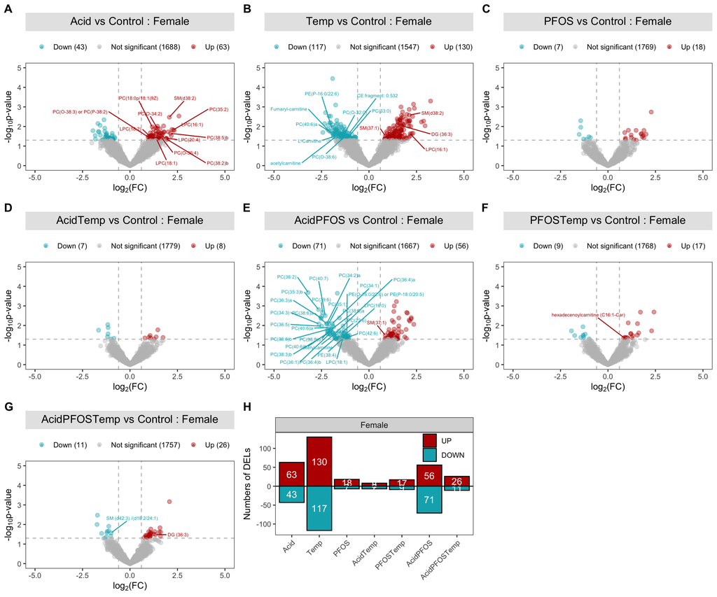

```r
ggarrange(Volcano_1, Volcano_2, Volcano_3, Volcano_4, Volcano_5, Volcano_6, Volcano_7,CountPlot_female,  ncol = 3, nrow = 3, labels = "AUTO")
```

*Fig. 8. Lipids expression analyses comparing treatment groups to the control, in female.* Panels (A–G) show volcano plots for the contrasts: (A) Acid vs. Control, (B) Temp vs. Control, (C) PFOS vs. Control, (D) AcidTemp vs. Control, (E) AcidPFOS vs. Control, (F) PFOSTemp vs. Control, and (G) AcidPFOSTemp vs. Control. The X-axis represents the log₂ fold change (FC), and the Y-axis represents the −log₁₀(p-value) for all lipids (known and unknown). The horizontal line indicates the p-value threshold of 0.05 (on a logarithmic scale). Red dots denote upregulated lipids, blue dots lipids metabolites, and grey dots unchanged lipids. Panel (H) shows a count plot summarizing the differentially expressed lipids (DELs) across all contrasts.

## 7.4 UpSet plot

UpSet plot provides an efficient way to visualize intersections of multiple sets compared to the traditional approaches, i.e. the Venn Diagram. [ComplexHeatmap](https://jokergoo.github.io/ComplexHeatmap-reference/book/upset-plot.html) [UpSetR](https://cran.r-project.org/web/packages/UpSetR/vignettes/basic.usage.html)

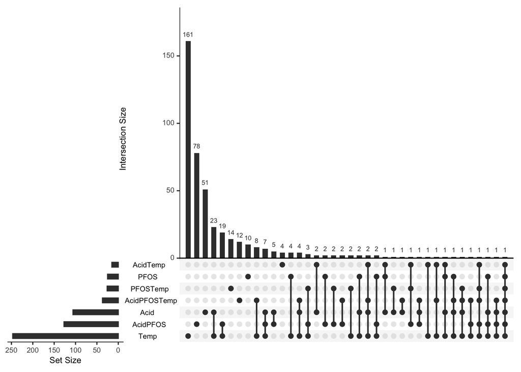

```r
library("UpSetR")

# Metabolite of interest (DEM for each condition)
lt<- list(
  "Acid" = DEM_Acid_Female$Compound,
  "Temp" = DEM_Temp_Female$Compound,
  "PFOS" = DEM_PFOS_Female$Compound,
  "AcidTemp" = DEM_AcidTemp_Female$Compound,
  "PFOSTemp" = DEM_PFOSTemp_Female$Compound,
  "AcidPFOS" = DEM_AcidPFOS_Female$Compound,
  "AcidPFOSTemp" = DEM_AcidPFOSTemp_Female$Compound)

UpSetR::upset(fromList(lt),
  order.by = "freq",       # order intersections by frequency
  keep.order = FALSE,       # keep the order of sets as in the list
  sets = names(lt))   # explicitly define all sets to include
```

*Fig. 9. UpSet plot showing intersections of differentially expressed Lipids (DELs) across treatment groups.* Horizontal bars indicate the total number of DELs per group, and vertical bars show the number of DELs shared among specific combinations of groups. Single dots represent group-specific DELs, while connected dots indicate shared DELs

## 7.5 Combinations vs single_stressor

- A low DELs count in a comparison means the combination have similar profiles to the single stressor.
- A high DELs count means the combination is different from the stressor alone.

```r
library("limma")
# Single vs combination comparisons
# drop unused factor levels
metadata$Sex <- droplevels(metadata$Sex)
metadata$Condition <- droplevels(metadata$Condition)
metadata$Exposure <- droplevels(metadata$Exposure)

# keep only matching samples in scaled_counts
centred_counts <- centred_counts[, rownames(metadata)]

# confirm alignment
stopifnot(all(colnames(centred_counts) == rownames(metadata)))

# Recreate the design matrix
design <- model.matrix(~ 0 + Condition + Exposure, data = metadata)
colnames(design)
```

```
## [1] "ConditionAcid"         "ConditionAcidPFOS"     "ConditionAcidPFOSTemp"
## [4] "ConditionAcidTemp"     "ConditionControl"      "ConditionPFOS"
## [7] "ConditionPFOSTemp"     "ConditionTemp"         "Exposureexpo_3"
```

```r
fit <- lmFit(centred_counts, design)

# contrast matix
contr.matrix<-makeContrasts(
  AcidTemp_vs_Acid = ConditionAcidTemp - ConditionAcid, # AcidTemp vs. Acid and Temp
  AcidTemp_vs_Temp = ConditionAcidTemp - ConditionTemp,
  PFOSTemp_vs_PFOS = ConditionPFOSTemp - ConditionPFOS,  # PFOSTemp vs. PFOS and Temp
  PFOSTemp_vs_Temp = ConditionPFOSTemp - ConditionTemp,
  AcidPFOS_vs_Acid = ConditionAcidPFOS - ConditionAcid,  # AcidPFOS vs. Acid and PFOS
  AcidPFOS_vs_PFOS = ConditionAcidPFOS - ConditionPFOS,
  AcidPFOSTemp_vs_Acid = ConditionAcidPFOSTemp - ConditionAcid,   # AcidPFOSTemp vs. Acid, Temp and PFOS
  AcidPFOSTemp_vs_PFOS = ConditionAcidPFOSTemp - ConditionPFOS,
  AcidPFOSTemp_vs_Temp = ConditionAcidPFOSTemp - ConditionTemp,
  AcidPFOSTemp_vs_AcidTemp = ConditionAcidPFOSTemp - ConditionAcidTemp, # AcidPFOSTemp vs.Secondary stressor combinaison
  AcidPFOSTemp_vs_PFOSTemp = ConditionAcidPFOSTemp - ConditionPFOSTemp,
  AcidPFOSTemp_vs_AcidPFOS= ConditionAcidPFOSTemp - ConditionAcidPFOS,
  levels = design)

# contrast matix
colnames(design)
```

```
## [1] "ConditionAcid"         "ConditionAcidPFOS"     "ConditionAcidPFOSTemp"
## [4] "ConditionAcidTemp"     "ConditionControl"      "ConditionPFOS"
## [7] "ConditionPFOSTemp"     "ConditionTemp"         "Exposureexpo_3"
```

```r
fit <- lmFit(centred_counts, design)
fit2 <- contrasts.fit(fit, contr.matrix)
fit3 <- eBayes(fit2)

summary(decideTests(fit3))
```

```
##        AcidTemp_vs_Acid AcidTemp_vs_Temp PFOSTemp_vs_PFOS PFOSTemp_vs_Temp
## Down                  0                0                0                0
## NotSig             1794             1794             1794             1794
## Up                    0                0                0                0
##        AcidPFOS_vs_Acid AcidPFOS_vs_PFOS AcidPFOSTemp_vs_Acid
## Down                 54                0                    0
## NotSig             1740             1794                 1794
## Up                    0                0                    0
##        AcidPFOSTemp_vs_PFOS AcidPFOSTemp_vs_Temp AcidPFOSTemp_vs_AcidTemp
## Down                      0                    0                        0
## NotSig                 1794                 1794                     1794
## Up                        0                    0                        0
##        AcidPFOSTemp_vs_PFOSTemp AcidPFOSTemp_vs_AcidPFOS
## Down                          0                        0
## NotSig                     1794                     1794
## Up                            0                        0
```

```r
# Get limma result
results_AcidTemp_vs_Acid <-topTable(fit3, coef="AcidTemp_vs_Acid", sort.by="P", number = Inf)
results_AcidTemp_vs_Temp <- topTable(fit3, coef="AcidTemp_vs_Temp", sort.by="P", number = Inf)
results_PFOSTemp_vs_PFOS <- topTable(fit3, coef="PFOSTemp_vs_PFOS", sort.by="P", number = Inf)
results_PFOSTemp_vs_Temp <- topTable(fit3, coef="PFOSTemp_vs_Temp", sort.by="P", number = Inf)
results_AcidPFOS_vs_Acid <- topTable(fit3, coef="AcidPFOS_vs_Acid", sort.by="P", number = Inf)
results_AcidPFOS_vs_PFOS <- topTable(fit3, coef="AcidPFOS_vs_PFOS", sort.by="P", number = Inf)
results_AcidPFOSTemp_vs_Acid <- topTable(fit3, coef="AcidPFOSTemp_vs_Acid", sort.by="P", number = Inf)
results_AcidPFOSTemp_vs_PFOS <- topTable(fit3, coef="AcidPFOSTemp_vs_PFOS", sort.by="P", number = Inf)
results_AcidPFOSTemp_vs_Temp <- topTable(fit3, coef="AcidPFOSTemp_vs_Temp", sort.by="P", number = Inf)
results_AcidPFOSTemp_vs_AcidTemp <- topTable(fit3, coef="AcidPFOSTemp_vs_AcidTemp", sort.by="P", number = Inf)
results_AcidPFOSTemp_vs_PFOSTemp<- topTable(fit3, coef="AcidPFOSTemp_vs_PFOSTemp", sort.by="P", number = Inf)
results_AcidPFOSTemp_vs_AcidPFOS <- topTable(fit3, coef="AcidPFOSTemp_vs_AcidPFOS", sort.by="P", number = Inf)

# Annotate result data
results_AcidTemp_vs_Acid$Treatment <- "AcidTemp_vs_Acid"
results_AcidTemp_vs_Temp$Treatment <- "AcidTemp_vs_Temp"
results_PFOSTemp_vs_PFOS$Treatment <- "PFOSTemp_vs_PFOS"
results_PFOSTemp_vs_Temp$Treatment <- "PFOSTemp_vs_Temp"
results_AcidPFOS_vs_Acid$Treatment <- "AcidPFOS_vs_Acid"
results_AcidPFOS_vs_PFOS$Treatment <- "AcidPFOS_vs_PFOS"
results_AcidPFOSTemp_vs_Acid$Treatment <- "AcidPFOSTemp_vs_Acid"
results_AcidPFOSTemp_vs_PFOS$Treatment <- "AcidPFOSTemp_vs_PFOS"
results_AcidPFOSTemp_vs_Temp$Treatment <- "AcidPFOSTemp_vs_Temp"
results_AcidPFOSTemp_vs_AcidTemp$Treatment <-"AcidPFOSTemp_vs_AcidTemp"
results_AcidPFOSTemp_vs_PFOSTemp$Treatment<- "AcidPFOSTemp_vs_PFOSTemp"
results_AcidPFOSTemp_vs_AcidPFOS$Treatment <- "AcidPFOSTemp_vs_AcidPFOS"

# all pairwise combination result
results_Pairwise <- rbind(results_AcidTemp_vs_Acid,
                     results_AcidTemp_vs_Temp,
                     results_PFOSTemp_vs_PFOS,
                     results_PFOSTemp_vs_Temp,
                     results_AcidPFOS_vs_Acid,
                     results_AcidPFOS_vs_PFOS,
                     results_AcidPFOSTemp_vs_Acid,
                     results_AcidPFOSTemp_vs_PFOS,
                     results_AcidPFOSTemp_vs_Temp,
                     results_AcidPFOSTemp_vs_AcidTemp,
                     results_AcidPFOSTemp_vs_PFOSTemp,
                     results_AcidPFOSTemp_vs_AcidPFOS)

results_Pairwise$Sex <- "Female"
results_Pairwise$Compound <- rownames(results_Pairwise)

# Subset your group of interest
results_Pairwise<- results_Pairwise[, c("Compound", "logFC","P.Value", "t", "Treatment", "Sex")]

# rename
colnames(results_Pairwise)[colnames(results_Pairwise) == "P.Value"] <- "pval"
colnames(results_Pairwise)[colnames(results_Pairwise) == "logFC"] <- "log2fc"

# Add a column to the data frame to specify if they are UP- or DOWN- regulated (log2fc respectively positive or negative)
results_Pairwise$diffexpressed <- "NO"
# if log2Foldchange > 0.6 and pvalue < 0.05, set as "UP"
results_Pairwise$diffexpressed[results_Pairwise$log2fc > 0.6 & results_Pairwise$pval < 0.05] <- "UP"
# if log2Foldchange < -0.6 and pvalue < 0.05, set as "DOWN"
results_Pairwise$diffexpressed[results_Pairwise$log2fc < -0.6 & results_Pairwise$pval < 0.05] <- "DOWN"

# Subset differential feature
DEL_results_Pairwise <- results_Pairwise[results_Pairwise$diffexpressed != "NO", ]

DEL_results_Pairwise %>%
  group_by(Treatment, diffexpressed) %>%
  summarise(Count = n(), .groups = "drop")
```

```
## # A tibble: 24 × 3
##    Treatment                diffexpressed Count
##    <chr>                    <chr>         <int>
##  1 AcidPFOSTemp_vs_Acid     DOWN             33
##  2 AcidPFOSTemp_vs_Acid     UP               24
##  3 AcidPFOSTemp_vs_AcidPFOS DOWN             42
##  4 AcidPFOSTemp_vs_AcidPFOS UP               62
##  5 AcidPFOSTemp_vs_AcidTemp DOWN              6
##  6 AcidPFOSTemp_vs_AcidTemp UP                5
##  7 AcidPFOSTemp_vs_PFOS     DOWN             11
##  8 AcidPFOSTemp_vs_PFOS     UP               14
##  9 AcidPFOSTemp_vs_PFOSTemp DOWN             29
## 10 AcidPFOSTemp_vs_PFOSTemp UP               19
## # ℹ 14 more rows
```

# 8 Enrich Pathway

`/!\` The input table provided to Mummichog included the complete feature list, necessary to model the background distribution, with m/z values and retention times to enhance metabolite annotation accuracy ([Mummichog](https://www.metaboanalyst.ca/Secure/mummichog/LibraryView.xhtml)).

[Mummichog](https://www.metaboanalyst.ca/Secure/mummichog/LibraryView.xhtml)

[Mummichog R](https://www.metaboanalyst.ca/resources/vignettes/Functional_Analysis_global_metabolomics.html)

**Useful links:**

- Comprehensive investigation of pathway enrichment methods for functional interpretation of LC–MS global metabolomics data [(Lu et al, 2022)](https://academic.oup.com/bib/article/24/1/bbac553/6960976).
- Comparison of popular enrichment methods for untargeted in vitro metabolomics [(Schermer et al, 2025)](https://doi.org/10.1007/s11306-025-02309-0).
- Environmental chemicals and endogenous metabolites in bile of USA and Norway patients with primary sclerosing cholangitis [(Grant et al 2023)](https://doi.org/10.1093/exposome/osac011).
- Global metabolomic alterations associated with endocrine-disrupting chemicals among pregnant individuals and newborns [(Puvvula et al, 2025)](https://doi.org/10.1007/s11306-024-02219-7)

```r
Data_Pathway <- read_csv2("/Users/baptisteducarme/Desktop/EpiCLim-F0-liver-female/Lipids/EPICLIM_F0_Liver_Pathway_lipid_Female.csv")
Data_Pathway <- Data_Pathway[Data_Pathway$P_Gamma < 0.05 & Data_Pathway$Hits_sig >= 3,]
head(Data_Pathway)
```

```
## # A tibble: 6 × 19
##   Pathway     Pathway_total Hits_total Hits_sig Expected P_Fisher P_EASE P_Gamma
##   <chr>               <dbl>      <dbl>    <dbl>    <dbl>    <dbl>  <dbl>   <dbl>
## 1 Linoleate …            30          6        3    0.346   0.0368  0.281 6.31e-4
## 2 Glycosphin…            56          9        4    0.953   0.0536  0.206 6.77e-4
## 3 Omega-3 fa…            38          3        3    0.693   0.141   0.488 9.86e-4
## 4 Glyceropho…           146         13        4    1.47    0.163   0.394 1.08e-3
## 5 Squalene a…            53          9        3    0.346   0.305   1     2.02e-3
## 6 De novo fa…            73          7        3    1.56    0.478   0.793 4.49e-3
## # ℹ 11 more variables: Emp_Hits <dbl>, Empirical <dbl>, AdjP_Fisher <dbl>,
## #   AdjP_EASE <dbl>, AdjP_Gamma <dbl>, Pathway_Number <chr>, cpd_hits <chr>,
## #   Condition <chr>, Sex <chr>, EnrichFactor <dbl>, BiologicalFunction <chr>
```

Pathways not annotated in vertebrates or specific to plant/microbial metabolism were excluded from downstream biological interpretation.

```r
pathway_groups <-list("Glycan biosynthesis and metabolism" = c(
  "Sialic acid metabolism",
  "Aminosugars metabolism",
  "Keratan sulfate biosynthesis",
  "Glycosphingolipid biosynthesis - globoseries",
  "Glycosphingolipid biosynthesis - ganglioseries",
  "Glycosphingolipid biosynthesis - lactoseries",
  "Glycosphingolipid biosynthesis - neolactoseries",
  "Blood Group Biosynthesis",
  "O-Glycan biosynthesis",
  "Glycosphingolipid metabolism",
  "N-Glycan biosynthesis",
  "N-Glycan Degradation",
  "Keratan sulfate degradation",
  "Chondroitin sulfate degradation",
  "Heparan sulfate degradation",
  "Phosphatidylinositol phosphate metabolism",
  "Glycosylphosphatidylinositol(GPI)-anchor biosynthesis"),
  "Carbohydrate metabolism" = c( "Pyruvate Metabolism",
    "Glycolysis and Gluconeogenesis",
    "Pentose phosphate pathway",
    "Propanoate metabolism",
    "Glyoxylate and Dicarboxylate Metabolism",
    "Fructose and mannose metabolism",
    "Galactose metabolism",
    "Hexose phosphorylation",
    "Starch and Sucrose Metabolism",
    "Pentose and Glucuronate Interconversions",
    "Butanoate metabolism"),
  "Nucleotide" = c(
    "Purine metabolism",
    "Pyrimidine metabolism"),
  "Amino acid" = c(
    "Glycine- serine- alanine and threonine metabolism",
    "Valine- leucine and isoleucine degradation",
    "Tyrosine metabolism",
    "Methionine and cysteine metabolism",
    "Tryptophan metabolism",
    "Lysine metabolism",
    "Alanine and Aspartate Metabolism",
    "Aspartate and asparagine metabolism",
    "Arginine and Proline Metabolism",
    "Histidine metabolism",
    "Selenoamino acid metabolism",
    "Beta-Alanine metabolism",
    "Glutathione Metabolism",
    "Glutamate metabolism"),
  "Cofactors and vitamins" = c(
    "Vitamin A (retinol) metabolism",
    "Vitamin B1 (thiamin) metabolism",
    "Vitamin B3 (nicotinate and nicotinamide) metabolism",
    "Vitamin B6 (pyridoxine) metabolism",
    "Ascorbate (Vitamin C) and Aldarate Metabolism",
    "Biopterin metabolism",
    "Vitamin E metabolism",
    "Vitamin H (biotin) metabolism",
    "Ubiquinone Biosynthesis"),
  "Lipid metabolism" = c(
    "Mono-unsaturated fatty acid beta-oxidation",
    "De novo fatty acid biosynthesis",
    "Fatty Acid Metabolism",
    "Glycerophospholipid metabolism",
    "Fatty acid activation",
    "Arachidonic acid metabolism",
    "Saturated fatty acids beta-oxidation",
    "Di-unsaturated fatty acid beta-oxidation",
    "Squalene and cholesterol biosynthesis",
    "Omega-3 fatty acid metabolism",
    "Carnitine shuttle",
    "Linoleate metabolism",
    "Bile acid biosynthesis",
    "Putative anti-Inflammatory metabolites formation from EPA",
    "C21-steroid hormone biosynthesis and metabolism",
    "Omega-6 fatty acid metabolism",
    "Prostaglandin formation from arachidonate",
    "Androgen and estrogen biosynthesis and metabolism"),
  "Other" = c(
    "Alkaloid biosynthesis II",
    "Leukotriene metabolism",
    "Xenobiotics metabolism",
    "Urea cycle/amino group metabolism"))

# Create a named vector for easy lookup
pathway_to_function <- unlist(lapply(names(pathway_groups), function(name) {
  setNames(rep(name, length(pathway_groups[[name]])), pathway_groups[[name]])
}))

# Add BiologicalFunction column to your data frame
Data_Pathway <- Data_Pathway %>%
  mutate(BiologicalFunction = pathway_to_function[as.character(Pathway)]) %>%
  # For pathways not in the list, assign "Unclassified"
  mutate(BiologicalFunction = ifelse(is.na(BiologicalFunction), "Unclassified", BiologicalFunction))
```

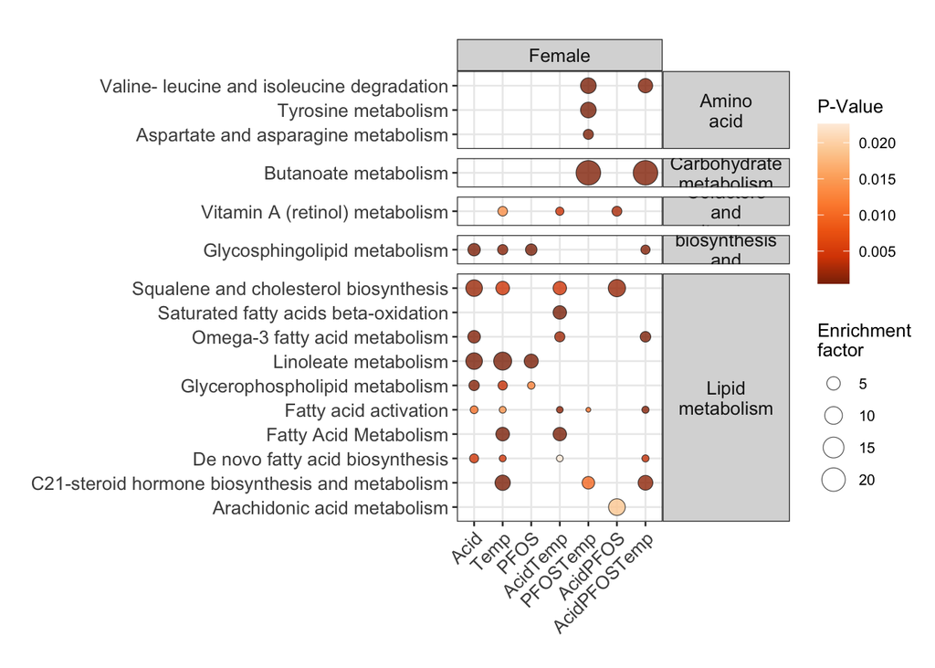

```r
Data_Pathway$Condition <- factor(Data_Pathway$Condition, levels = c("Acid", "Temp", "PFOS","AcidTemp", "PFOSTemp","AcidPFOS", "AcidPFOSTemp"))

pathway_order <- Data_Pathway %>%
  distinct(Pathway, BiologicalFunction) %>%
  arrange(BiologicalFunction, Pathway) %>%
  pull(Pathway)

Data_Pathway <- Data_Pathway %>%
  mutate(
    Pathway = factor(Pathway, levels = pathway_order),
    Condition = factor(Condition, levels = c("Acid", "Temp", "PFOS", "AcidTemp", "PFOSTemp", "AcidPFOS", "AcidPFOSTemp")))

Plot_Pathway_female<-ggplot(Data_Pathway) +
  aes(x = Condition,
    y = Pathway,
    fill = P_Gamma,           # use fill for the inside color
    size = EnrichFactor) +
  facet_grid(BiologicalFunction ~ Sex, scales = "free_y", space = "free_y",
             labeller = labeller(BiologicalFunction = function(x) {
               sapply(x, function(y) paste(strwrap(y, width = 10), collapse = "\n"))
             })) +
  geom_point(shape = 21, color = "grey10", stroke = 0.3, alpha = 0.8) +  # thin black outline
  labs(
    title = "",
    x = "",
    y = "",
    fill = "P-Value",
    size = "Enrichment \nfactor"
  ) +
  scale_fill_distiller(palette = "Oranges") +
   theme_bw(base_size = 10) +
  theme(axis.text.x = element_text(angle = 45, hjust = 1, size = 10),
        axis.text = element_text(size = 10),
        strip.text.x = element_text(size = 10),
        strip.text.y = element_text(size = 10, angle = 0))+
  scale_x_discrete(drop = FALSE) +   # print the condition without affected pathway
  scale_y_discrete(drop = TRUE)


Plot_Pathway_female
```

*Fig. 10. Pathway enrichment analysis of liver lipidomic using the Mummichog algorithm.* Significantly enriched pathways (Gamma p-value < 0.05 and Hits sig ≥3) were identified based on the top 10% of lipid features with the lowest raw p-values. The enrichment factor represents the ratio between the observed number of significant hits and the expected number of hits per pathway.

## 8.1 Upsetplot.

https://jokergoo.github.io/ComplexHeatmap-reference/book/upset-plot.html https://cran.r-project.org/web/packages/UpSetR/vignettes/basic.usage.html

UpSet plot provides an efficient way to visualize intersections of multiple sets compared to the traditional approaches, i.e. the Venn Diagram. To visualise how many mummichog pathways are shared between conditions and which combinations of conditions share the most pathways, an UpSet plot was generated. Horizontal bars on the left show the total number of significant pathways per condition. Vertical bars show the number of pathways in each intersection. Dots connected by lines below indicate which conditions share those pathways.

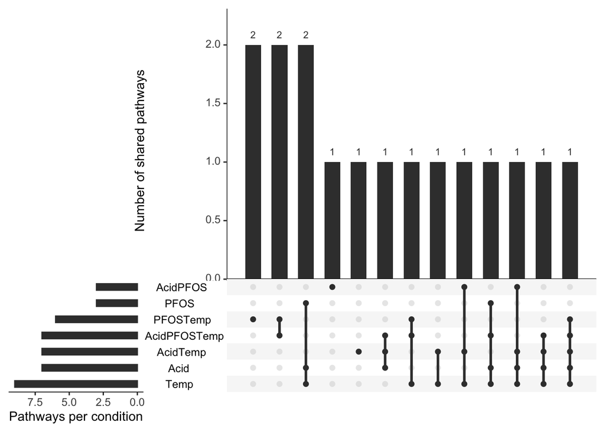

```r
library("UpSetR")
library("grid")

# Metabolite of interest (DEM for each condition)
lt<- list(
  "Acid" = Data_Pathway[Data_Pathway$Condition == "Acid",]$Pathway,
  "Temp" = Data_Pathway[Data_Pathway$Condition == "Temp",]$Pathway,
  "PFOS" = Data_Pathway[Data_Pathway$Condition == "PFOS",]$Pathway,
  "AcidTemp" = Data_Pathway[Data_Pathway$Condition == "AcidTemp",]$Pathway,
  "PFOSTemp" = Data_Pathway[Data_Pathway$Condition == "PFOSTemp",]$Pathway,
  "AcidPFOS" = Data_Pathway[Data_Pathway$Condition == "AcidPFOS",]$Pathway,
  "AcidPFOSTemp" = Data_Pathway[Data_Pathway$Condition == "AcidPFOSTemp",]$Pathway)

UpSetR::upset(
  fromList(lt),
  order.by = "freq",
  sets = names(lt),
  decreasing = TRUE,
  mb.ratio = c(0.65, 0.35),
  text.scale = 1.3,
  point.size = 2,
  line.size = 1,
  mainbar.y.label = "Number of shared pathways",
  sets.x.label = "Pathways per condition",
  scale.sets = "identity")
```

*Fig. 11. UpSet plot showing the intersections of enriched pathways across treatment groups.* Horizontal bars indicate the total number of enriched pathways in each group, whereas vertical bars indicate the number of enriched pathways shared among specific combinations of groups. Single dots represent pathways uniquely enriched in a single group, while connected dots indicate pathways shared among multiple groups.